# First impressions and movement in schizophrenia

Statistical analysis pipeline

Statistical analysis report

2026-10-01

# 1 Introduction

This notebook reports the statistical analysis of first impressions formed about individuals with schizophrenia (SZ) and matched healthy controls (P), and the relationship between these impressions and the **quantity of body movement** (QoM) of the hands and of the head, extracted from short video stimuli.

The movement analysis uses four directional quantity-of-motion (QoM) features, extracted at the stimulus level:

- `move_hands_horizontal_qom_rate` — hand movement, horizontal (per second);
- `move_hands_vertical_qom_rate` — hand movement, vertical (per second);
- `move_head_horizontal_qom_rate` — head movement, horizontal (per second);
- `move_head_vertical_qom_rate` — head movement, vertical (per second).

These are first correlated, then reduced to a single overall movement component by PCA, which is used in the group and impression analyses.

This is the last step of the pipeline. Results are organised by hypothesis under `results/`: `descriptive/` (purely descriptive tables, no hypothesis test), `H1/` (group -> impression), `H2/` (group -> movement), `H3/` (movement -> impression), `H4/` (group and movement jointly), and `supplementary/` (scale reliability, the movement PCA construction, and exploratory/symptom correlations).

# 2 Materials and methods

## 2.1 Software

```r
R.version.string
```

```
## [1] "R version 4.5.2 (2025-10-31 ucrt)"
```

Analyses were performed in **R** with the following packages: `lme4`, `lmerTest`, `emmeans`, `performance`, `effectsize`, `psych`, `car`, `flextable`, `gt`, `ggplot2`, `patchwork`. The full session information is reported at the end of this document.

## 2.2 Statistical analyses

**Alpha level.** All inferential tests used a two-sided α = 0.05 unless otherwise specified.

**Group comparisons (P vs. SZ) at the stimulus level.** For each continuous variable, the test was selected automatically: (i) Shapiro–Wilk per group tested normality and Levene’s test tested homogeneity of variances; (ii) when both assumptions held, an independent-samples Student *t*-test was used; (iii) when variances differed, Welch’s *t*-test; (iv) when normality failed, the Wilcoxon rank-sum test. Effect sizes are Cohen’s *d* for *t*-tests and the rank-biserial correlation for Wilcoxon tests, each with a 95 % CI.

**Linear mixed models (LMM).** For analyses on the evaluation-level data (one row per observer × video), LMMs were fitted with `lmerTest` using restricted maximum likelihood (REML). Random intercepts were specified for observer and for video stimulus, `outcome ~ predictor(s) + (1 | obs_id) + (1 | vid)`. Denominator degrees of freedom and *p*-values were obtained via Satterthwaite’s approximation. For every LMM we report (a) the fixed-effect estimates with 95 % CI, (b) the marginal *R²* (variance explained by the fixed effects) and conditional *R²* (fixed + random effects) following Nakagawa & Schielzeth, and (c) an explicit **partition of the random variance**: the variance component and the proportion of the residual (unexplained) variance attributable to each random intercept (observer, video) and to the residual, together with the intraclass correlation (ICC = proportion of residual variance captured by the random intercepts). The additional variance accounted for by the random structure beyond the fixed effects is summarised by conditional *R²* − marginal *R²*. For the two-group models (total score and each item) a standardised mean-difference effect size (Cohen’s *d*, SZ − P) is additionally obtained from the estimated marginal means with `emmeans::eff_size()`. Model assumptions (normality of residuals, homoscedasticity, normality of the random-effect BLUPs, singularity and convergence) were checked numerically and visually with `performance::check_model()`.

**Aggregating the movement features.** The four directional QoM features (hands and head × horizontal and vertical) were first inter-correlated at the stimulus level (Pearson’s *r* when all features were approximately normal by Shapiro-Wilk, otherwise Spearman’s *ρ*). Given their strong inter-correlations, they were reduced by a principal component analysis on the z-standardised features. Sampling adequacy was checked (Kaiser-Meyer- Olkin measure; Bartlett’s test of sphericity); the number of components was determined by the Kaiser criterion (eigenvalue > 1) and parallel analysis, and a varimax (orthogonal) rotation was applied when more than one component was retained (no effect for a single component). Eigenvalues, communalities and a scree plot are reported. The dominant component — oriented so that higher scores indicate more movement and rescaled to unit SD — was used as a single *overall body movement* score in the subsequent analyses.

**Group difference in movement.** The group difference in overall body movement was tested on this aggregate score at the stimulus level, with the test auto-selected from normality and variance-homogeneity checks and reported with its effect size.

**Group and movement jointly.** The first-impression total-score model was then re-fitted with both diagnostic group and overall movement as fixed effects. This estimates the movement effect adjusting for group and quantifies the attenuation of the group difference once movement is accounted for (a mediation-style comparison, reported descriptively). Because group and movement are correlated at the stimulus level, their collinearity (VIF) is reported alongside.

**Robustness.** Because several impression models showed mild heteroscedasticity, the principal fixed effects were re-estimated with a non-parametric **cluster bootstrap** (resampling whole video stimuli with replacement), and compared with the model-based estimates as a sensitivity analysis. The bootstrap is valid for the crossed observer × video random structure, for which sandwich-type cluster-robust estimators are not defined.

**Correlations.** Spearman’s *ρ* was used throughout (no normality requirement, robust to the small SZ sample), with 95 % CIs from Fisher’s *z* transformation. Correlations among clinical variables are flagged as exploratory (post-hoc) per SAMPL.

**Multiple comparisons.** When several tests addressed one family of hypotheses, Benjamini–Hochberg (BH) false-discovery-rate correction was applied and the adjusted *p*-values are reported alongside the raw values (impression items: family of ten items; exploratory correlations: family of features within each clinical variable).

**Missing data.** No imputation was performed; each test uses complete cases on the variables involved, and sample sizes are reported per analysis.

# 3 Constants, helper functions and data loading

## 3.1 Packages, style helpers and paths

```r
suppressPackageStartupMessages({
  library(dplyr); library(tidyr); library(readr); library(stringr)
  library(purrr); library(tibble); library(ggplot2)
  library(lme4);  library(lmerTest); library(emmeans); library(performance)
  library(broom); library(broom.mixed); library(car); library(effectsize)
  library(psych); library(flextable); library(gt); library(officer)
  library(scales); library(patchwork)
})
# Colours, labels, fmt_*() helpers, theme_plos(), plos_table(), save_table()
# and save_figure() - the formatting/journal-style layer, kept separate so it
# can be tweaked without touching the analyses below.
source("style_helpers.R")
source("stat_helpers.R")

# ---- Movement variables (only the two total-QoM features) ------------------
MOVEMENT_VARS <- c(
  "move_hands_horizontal_qom_rate",  # hand movement, horizontal (QoM rate)
  "move_hands_vertical_qom_rate",    # hand movement, vertical (QoM rate)
  "move_head_horizontal_qom_rate",   # head movement, horizontal (QoM rate)
  "move_head_vertical_qom_rate"      # head movement, vertical (QoM rate)
)

IMPRESSION_ITEMS <- c(
  "imp_sympathique", "imp_bizarre_inversed", "imp_intelligente",
  "imp_appreciable", "imp_confiance", "imp_dominante",
  "imp_conversation", "imp_temps", "imp_voisin", "imp_assis"
)

ALPHA_LEVEL <- 0.05

# ---- Input path (processed data from 02_merge_data.Rmd) ------------------
PATH_DATA_PROC <- "../../data/merged"

# ---- Output paths: results organised by hypothesis --------------------------
RESULTS_DIR           <- "../../results"
RESULTS_DESCRIPTIVE   <- file.path(RESULTS_DIR, "descriptive")
RESULTS_H1             <- file.path(RESULTS_DIR, "H1")   # group -> impression
RESULTS_H2             <- file.path(RESULTS_DIR, "H2")   # group -> movement
RESULTS_H3             <- file.path(RESULTS_DIR, "H3")   # movement -> impression
RESULTS_H4             <- file.path(RESULTS_DIR, "H4")   # group + movement jointly
RESULTS_SUPPLEMENTARY <- file.path(RESULTS_DIR, "supplementary")

for (p in c(RESULTS_DESCRIPTIVE, RESULTS_H1, RESULTS_H2, RESULTS_H3, RESULTS_H4,
            RESULTS_SUPPLEMENTARY)) {
  dir.create(p, recursive = TRUE, showWarnings = FALSE)
}
```

## 3.2 Load processed data

```r
data_complete  <- read_csv(file.path(PATH_DATA_PROC, "data_complete.csv"),
                           show_col_types = FALSE)
data_stimuli   <- read_csv(file.path(PATH_DATA_PROC, "data_stimuli.csv"),
                           show_col_types = FALSE)
data_observers <- read_csv(file.path(PATH_DATA_PROC, "data_observers.csv"),
                           show_col_types = FALSE)

data_complete$stim_group <- factor(data_complete$stim_group, levels = c("P", "SZ"))
data_stimuli$stim_group  <- factor(data_stimuli$stim_group,  levels = c("P", "SZ"))

message(sprintf("data_complete : %d rows / data_stimuli : %d rows / data_observers : %d rows",
                nrow(data_complete), nrow(data_stimuli), nrow(data_observers)))
```

```
## data_complete : 910 rows / data_stimuli : 40 rows / data_observers : 91 rows
```

# 4 Results

## 4.1 Reliability of the first-impression scale

**Purpose.** Estimate the internal consistency of the 10 first-impression items used to compute the total impression score.

**Items used.** `imp_bizarre_inversed` is the recoded (reverse) version of `imp_bizarre`; only the inverted version is included in the score and in the reliability analysis.

```r
alpha_obj <- psych::alpha(
  data_complete[, IMPRESSION_ITEMS, drop = FALSE],
  check.keys = FALSE,
  warnings = FALSE
)
```

```
## Number of categories should be increased  in order to count frequencies.
```

```r
alpha_summary <- tibble(
  `N items` = length(IMPRESSION_ITEMS),
  `N observations` = sum(complete.cases(
    data_complete[, IMPRESSION_ITEMS]
  )),
  `Cronbach's α` = alpha_obj$total$raw_alpha
)

ft_alpha <- alpha_summary |>
  mutate(across(where(is.numeric), ~ fmt_num(.x, 3))) |>
  plos_table(
    title = "Internal consistency of the 10-item first-impression scale.",
    footnote = paste0(
      "Internal consistency was assessed using Cronbach's α. ",
      "imp_bizarre_inversed is the reverse-scored version of imp_bizarre."
    )
  )

ft_alpha
```

Internal consistency of the 10-item first-impression scale.

| N items | N observations | Cronbach's α |
| --- | --- | --- |
| 10.000 | 910.000 | 0.867 |

Internal consistency was assessed using Cronbach's α. imp_bizarre_inversed is the reverse-scored version of imp_bizarre.

```r
save_table(
  ft_alpha,
  "table_01_cronbach_alpha",
  RESULTS_SUPPLEMENTARY
)
```

## 4.2 Characteristics of stimulus participants

**Purpose.** Describe and compare the two stimulus groups (P vs. SZ) on demographic and general cognitive variables.

**Method.** Each continuous variable was tested with `auto_group_test()`, which selects between Student’s *t*-test, Welch’s *t*-test, and the Wilcoxon rank-sum test on the basis of Shapiro–Wilk and Levene tests. Gender is reported as count and column percentage; group differences in gender are tested with Pearson’s χ² (or Fisher’s exact when expected counts are < 5).

```r
vars_stim_continu <- c("stim_age", "stim_education",
                       "stim_BDI_II", "stim_fNART_errors", "stim_MOCA")

# --- Continuous variables: auto-test ----------------------------------------
stim_tests <- auto_group_test_multi(data_stimuli, vars_stim_continu,
                                    group_var = "stim_group",
                                    bh_correction = FALSE)

# --- Gender (chi-square / Fisher) -------------------------------------------
gender_tab <- table(data_stimuli$stim_gender, data_stimuli$stim_group)
gender_test <- if (any(chisq.test(gender_tab)$expected < 5)) {
  res <- fisher.test(gender_tab)
  list(name = "Fisher's exact", stat = NA_real_,
       df = NA_real_, p = res$p.value, es = NA, lo = NA, hi = NA)
} else {
  res <- chisq.test(gender_tab)
  v   <- effectsize::cramers_v(gender_tab)
  list(name = "χ²", stat = unname(res$statistic), df = unname(res$parameter),
       p = res$p.value, es = v$Cramers_v_adjusted,
       lo = v$CI_low, hi = v$CI_high)
}

# --- Build the publication table --------------------------------------------
n_p  <- sum(data_stimuli$stim_group == "P",  na.rm = TRUE)
n_sz <- sum(data_stimuli$stim_group == "SZ", na.rm = TRUE)

gender_rows <- data_stimuli |>
  count(stim_group, stim_gender) |>
  group_by(stim_group) |>
  mutate(pct = n / sum(n) * 100) |>
  ungroup() |>
  mutate(cell = sprintf("%d (%.1f%%)", n, pct)) |>
  select(stim_group, stim_gender, cell) |>
  pivot_wider(names_from = stim_group, values_from = cell)

gender_first_row <- tibble(
  Variable    = paste0("Gender, n (%)"),
  P_value     = gender_rows[[2]][1],
  SZ_value    = gender_rows[[3]][1],
  Test        = gender_test$name,
  Statistic   = if (!is.na(gender_test$stat))
                  sprintf("%s%s",
                          fmt_num(gender_test$stat, 2),
                          ifelse(is.na(gender_test$df), "",
                                 sprintf(" (df = %d)", gender_test$df)))
                else "—",
  p           = fmt_p(gender_test$p),
  `Effect size (95% CI)` = if (!is.na(gender_test$es))
    sprintf("V = %s %s", fmt_num(gender_test$es, 2),
            fmt_ci(gender_test$lo, gender_test$hi, 2))
    else "—"
)

continu_rows <- stim_tests |>
  mutate(
    Variable = paste0(pretty_label(outcome), ", mean (SD)"),
    P_value  = fmt_msd(mean_g1, sd_g1, 2),
    SZ_value = fmt_msd(mean_g2, sd_g2, 2),
    Test     = test,
    Statistic = ifelse(is.na(df),
                       fmt_num(statistic, 2),
                       sprintf("%s (df = %s)",
                               fmt_num(statistic, 2), fmt_num(df, 1))),
    p        = fmt_p(p_value),
    `Effect size (95% CI)` = sprintf("%s = %s %s",
                                     ifelse(str_detect(es_name, "Cohen"), "d", "r"),
                                     fmt_num(es, 2),
                                     fmt_ci(es_ci_lo, es_ci_hi, 2))
  ) |>
  select(Variable, P_value, SZ_value, Test, Statistic, p,
         `Effect size (95% CI)`)

stim_table_df <- bind_rows(continu_rows, gender_first_row) |>
  rename(!!sprintf("P (n = %d)", n_p) := P_value,
         !!sprintf("SZ (n = %d)", n_sz) := SZ_value)

if (nrow(gender_rows) > 1) {
  for (i in 2:nrow(gender_rows)) {
    stim_table_df <- add_row(
      stim_table_df,
      Variable = paste0("  ", gender_rows$stim_gender[i]),
      !!sprintf("P (n = %d)", n_p)  := gender_rows[[2]][i],
      !!sprintf("SZ (n = %d)", n_sz) := gender_rows[[3]][i],
      Test = "", Statistic = "", p = "", `Effect size (95% CI)` = ""
    )
  }
}

ft_stim <- plos_table(
  stim_table_df,
  title = "Demographic and cognitive characteristics of stimulus participants by group.",
  footnote = c(
    paste0("P, healthy controls; SZ, individuals with a diagnosis of schizophrenia. ",
           "SD, standard deviation; CI, confidence interval; ",
           "d, Cohen's d; V, Cramér's V."),
    paste0("Tests were selected automatically based on Shapiro-Wilk (normality) ",
           "and Levene (variance homogeneity) tests; p-values are two-sided.")
  )
)
ft_stim
```

Demographic and cognitive characteristics of stimulus participants by group.

| Variable | P (n = 20) | SZ (n = 20) | Test | Statistic | p | Effect size (95% CI) |
| --- | --- | --- | --- | --- | --- | --- |
| Age, mean (SD) | 33.25 (13.53) | 34.45 (7.61) | Wilcoxon rank-sum | 151.00 | .189 | r = -0.24 [-0.55, 0.11] |
| Education, mean (SD) | 14.95 (2.06) | 13.70 (2.89) | Wilcoxon rank-sum | 260.00 | .101 | r = 0.30 [-0.05, 0.59] |
| Bdi ii, mean (SD) | 6.05 (4.64) | 13.74 (8.35) | Wilcoxon rank-sum | 72.00 | <.001 | r = -0.62 [-0.80, -0.34] |
| Fnart errors, mean (SD) | 13.20 (4.81) | 14.25 (6.62) | Wilcoxon rank-sum | 188.50 | .765 | r = -0.06 [-0.40, 0.30] |
| Moca, mean (SD) | 27.00 (1.84) | 24.75 (2.57) | Student t-test | 3.18 (df = 38.0) | .003 | d = 1.01 [0.34, 1.66] |
| Gender, n (%) | 9 (45.0%) | 4 (20.0%) | χ² | 1.82 (df = 1) | .177 | V = 0.22 [0.00, 1.00] |
| H | 11 (55.0%) | 16 (80.0%) |  |  |  |  |

P, healthy controls; SZ, individuals with a diagnosis of schizophrenia. SD, standard deviation; CI, confidence interval; d, Cohen's d; V, Cramér's V.  
Tests were selected automatically based on Shapiro-Wilk (normality) and Levene (variance homogeneity) tests; p-values are two-sided.

```r
save_table(ft_stim, "table_02_stimuli_characteristics", RESULTS_DESCRIPTIVE)
```

## 4.3 SZ clinical characteristics

**Purpose.** Describe clinical characteristics of the SZ subgroup.

```r
sz_only <- data_stimuli |> filter(stim_group == "SZ")
vars_sz <- c("stim_PANSS_positive", "stim_PANSS_negative",
             "stim_PANSS_psychopathology",
             "stim_diagnostic_duration", "stim_chlorpro_mg")

sz_descr <- map_dfr(vars_sz, function(v) {
  x <- sz_only[[v]]
  shap <- if (sum(!is.na(x)) >= 3) shapiro.test(x)$p.value else NA_real_
  tibble(
    Variable           = pretty_label(v),
    n                  = sum(!is.na(x)),
    `Mean (SD)`        = fmt_msd(mean(x, na.rm = TRUE), sd(x, na.rm = TRUE), 2),
    `Median [Q1, Q3]`  = fmt_med_iqr(x, 2),
    Range              = sprintf("%s - %s",
                                 fmt_num(suppressWarnings(min(x, na.rm = TRUE)), 1),
                                 fmt_num(suppressWarnings(max(x, na.rm = TRUE)), 1)),
    `Shapiro-Wilk p`   = fmt_p(shap)
  )
})

ft_sz <- plos_table(
  sz_descr,
  title = "Clinical characteristics of the SZ subgroup.",
  footnote = paste0("Q1, first quartile; Q3, third quartile. ",
                    "PANSS, Positive and Negative Syndrome Scale. ",
                    "chlorpro mg = chlorpromazine-equivalent daily dose.")
)
ft_sz
```

Clinical characteristics of the SZ subgroup.

| Variable | n | Mean (SD) | Median [Q1, Q3] | Range | Shapiro-Wilk p |
| --- | --- | --- | --- | --- | --- |
| Panss positive | 15 | 10.67 (4.27) | 9.00 [8.00, 13.50] | 5.0 - 19.0 | .337 |
| Panss negative | 15 | 13.13 (4.17) | 13.00 [11.00, 15.00] | 7.0 - 23.0 | .287 |
| Panss psychopathology | 15 | 31.00 (6.99) | 33.00 [25.50, 35.00] | 20.0 - 41.0 | .225 |
| Diagnostic duration | 19 | 9.16 (6.15) | 8.00 [6.00, 11.00] | 1.0 - 23.0 | .090 |
| Chlorpro mg | 20 | 438.75 (319.69) | 300.00 [200.00, 725.00] | 100.0 - 1175.0 | .013 |

Q1, first quartile; Q3, third quartile. PANSS, Positive and Negative Syndrome Scale. chlorpro mg = chlorpromazine-equivalent daily dose.

```r
save_table(ft_sz, "table_03_SZ_clinical_descriptives", RESULTS_DESCRIPTIVE)
```

## 4.4 Characteristics of observers

**Purpose.** Describe the observer panel that rated the stimulus videos.

```r
n_obs   <- nrow(data_observers)
obs_age <- data_observers$obs_age

obs_continuous_row <- tibble(
  Variable     = "Age (years)",
  n            = sum(!is.na(obs_age)),
  Summary      = fmt_msd(mean(obs_age, na.rm = TRUE),
                         sd(obs_age,   na.rm = TRUE), 1),
  Distribution = "Mean (SD)"
)


obs_cat_rows <- list(
  obs_gender    = "Gender",
  obs_pro_sante = "Health-care professional"
) |>
  imap_dfr(function(label, var) {
    data_observers |>
      filter(!is.na(.data[[var]])) |>
      count(.data[[var]]) |>
      mutate(pct = n / sum(n) * 100,
             Variable = label,
             Level    = as.character(.data[[var]]),
             Summary  = sprintf("%d (%.1f%%)", n, pct)) |>
      select(Variable, Level, Summary)
  })

ft_obs_cont <- plos_table(
  obs_continuous_row,
  title    = "Observer panel: age summary.",
  footnote = sprintf("Total N observers = %d.", n_obs)
)
ft_obs_cont
```

Observer panel: age summary.

| Variable | n | Summary | Distribution |
| --- | --- | --- | --- |
| Age (years) | 91 | 26.5 (11.6) | Mean (SD) |

Total N observers = 91.

```r
save_table(ft_obs_cont, "table_04a_observers_age", RESULTS_DESCRIPTIVE)

ft_obs_cat <- plos_table(
  obs_cat_rows,
  title    = "Observer panel: gender and health-care professional status.",
  footnote = sprintf("Total N observers = %d.", n_obs)
)
ft_obs_cat
```

Observer panel: gender and health-care professional status.

| Variable | Level | Summary |
| --- | --- | --- |
| Gender | F | 68 (74.7%) |
| Gender | M | 23 (25.3%) |
| Health-care professional | 1 | 6 (6.6%) |
| Health-care professional | 2 | 10 (11.0%) |
| Health-care professional | 3 | 75 (82.4%) |

Total N observers = 91.

```r
save_table(ft_obs_cat, "table_04b_observers_categorical", RESULTS_DESCRIPTIVE)
```

Health-care pro 1 = they are health care pro health-care pro 2 = they are mental health care pro health-care pro 3 = they are neither

## 4.5 First impressions: descriptive statistics by group

**Purpose.** Describe the total first-impression score and each of the ten items by group (P vs. SZ) at the evaluation level (one row per observer × video). These are descriptive only; the inferential group comparison is the linear mixed model in the next section (H1).

```r
imp_targets <- c("imp_total_score", IMPRESSION_ITEMS)

imp_descr <- map_dfr(imp_targets, function(v) {
  d <- data_complete |> filter(!is.na(.data[[v]]))
  by_group <- d |>
    group_by(stim_group) |>
    summarise(n = dplyr::n(),
              m = mean(.data[[v]]),
              s = sd(.data[[v]]),
              med = median(.data[[v]]),
              q1  = quantile(.data[[v]], 0.25),
              q3  = quantile(.data[[v]], 0.75),
              .groups = "drop")
  p_row <- by_group |> filter(stim_group == "P")
  s_row <- by_group |> filter(stim_group == "SZ")
  tibble(
    Variable         = ifelse(v == "imp_total_score",
                              "Total impression score", pretty_label(v)),
    `P n`            = p_row$n,
    `P mean (SD)`    = fmt_msd(p_row$m, p_row$s, 2),
    `P median [IQR]` = sprintf("%s [%s, %s]",
                               fmt_num(p_row$med, 2),
                               fmt_num(p_row$q1, 2), fmt_num(p_row$q3, 2)),
    `SZ n`           = s_row$n,
    `SZ mean (SD)`   = fmt_msd(s_row$m, s_row$s, 2),
    `SZ median [IQR]`= sprintf("%s [%s, %s]",
                               fmt_num(s_row$med, 2),
                               fmt_num(s_row$q1, 2), fmt_num(s_row$q3, 2))
  )
})

ft_imp_descr <- plos_table(
  imp_descr,
  title    = "Descriptive statistics of the first-impression scores by group.",
  footnote = c(
    paste0("Evaluation-level data (one row per observer x video). ",
           "n is the number of evaluations contributing to each group."),
    paste0("Values are descriptive; the group difference is tested with a ",
           "linear mixed model accounting for the observer x video structure ",
           "(see H1).")
  )
)
ft_imp_descr
```

Descriptive statistics of the first-impression scores by group.

| Variable | P n | P mean (SD) | P median [IQR] | SZ n | SZ mean (SD) | SZ median [IQR] |
| --- | --- | --- | --- | --- | --- | --- |
| Total impression score | 455 | 560.57 (160.69) | 562.00 [456.00, 680.00] | 455 | 489.65 (160.02) | 498.00 [383.50, 607.00] |
| Sympathique | 455 | 61.12 (21.78) | 63.00 [49.00, 77.00] | 455 | 52.65 (22.68) | 52.00 [38.50, 69.00] |
| Bizarre inversed | 455 | 64.87 (26.87) | 68.00 [50.00, 88.00] | 455 | 56.80 (27.87) | 54.00 [36.50, 81.00] |
| Intelligente | 455 | 60.24 (19.64) | 58.00 [50.00, 73.00] | 455 | 52.93 (19.11) | 52.00 [46.00, 64.00] |
| Appreciable | 455 | 60.36 (21.32) | 61.00 [49.00, 74.00] | 455 | 53.02 (22.87) | 53.00 [39.00, 69.00] |
| Confiance | 455 | 54.28 (20.58) | 52.00 [42.00, 68.00] | 455 | 46.81 (22.43) | 50.00 [31.00, 60.00] |
| Dominante | 455 | 41.29 (28.38) | 42.00 [16.00, 64.00] | 455 | 41.68 (28.99) | 38.00 [17.00, 64.00] |
| Conversation | 455 | 53.46 (24.24) | 53.00 [36.00, 70.50] | 455 | 44.61 (24.60) | 48.00 [25.00, 61.00] |
| Temps | 455 | 50.13 (24.11) | 52.00 [33.50, 67.50] | 455 | 42.08 (23.89) | 44.00 [24.00, 58.00] |
| Voisin | 455 | 55.13 (23.52) | 54.00 [43.00, 71.50] | 455 | 47.71 (24.64) | 50.00 [31.00, 65.50] |
| Assis | 455 | 59.69 (24.65) | 61.00 [45.50, 78.00] | 455 | 51.36 (25.61) | 51.00 [32.00, 71.50] |

Evaluation-level data (one row per observer x video). n is the number of evaluations contributing to each group.  
Values are descriptive; the group difference is tested with a linear mixed model accounting for the observer x video structure (see H1).

```r
save_table(ft_imp_descr, "table_05_impression_descriptives", RESULTS_DESCRIPTIVE)
```

# 5 H1 - Does diagnostic group predict first impressions?

## 5.1 Total score (linear mixed model)

**Purpose.** Test whether the total first-impression score differs between the SZ and P groups while accounting for the nested structure of the data (each observer rates several videos, each video is rated by several observers).

**Variables.** Outcome: `imp_total_score`. Fixed effect: `stim_group` (reference = P). Random intercepts: observer (`obs_id`) and video (`vid`).

```r
m_total <- fit_lmm(data_complete, "imp_total_score", "stim_group")
res_total <- extract_lmm_results(m_total, "stim_group")

# Standardised mean-difference effect size (Cohen's d, SZ - P)
d_total <- lmm_cohens_d(m_total, "stim_group", ref = "P")

# Adjusted means (emmeans) for plotting and reporting
emm_total <- emmeans::emmeans(m_total, ~ stim_group) |>
  as.data.frame() |> normalize_emm_ci()

lmm_total_tab <- tibble(
  Outcome     = "Total impression score",
  Comparison  = "SZ vs. P (P = reference)",
  `β (95% CI)`= sprintf("%s %s",
                        fmt_num(res_total$estimate, 2),
                        fmt_ci(res_total$ci_lo, res_total$ci_hi, 2)),
  SE          = fmt_num(res_total$se, 2),
  df          = fmt_num(res_total$df, 1),
  t           = fmt_num(res_total$statistic, 2),
  p           = fmt_p(res_total$p_value),
  `Cohen's d (95% CI)` = sprintf("%s %s",
                                 fmt_num(d_total$d, 2),
                                 fmt_ci(d_total$d_lo, d_total$d_hi, 2)),
  `R² marginal`    = fmt_num(res_total$r2_marg, 3),
  `R² conditional` = fmt_num(res_total$r2_cond, 3),
  `f²`        = fmt_num(res_total$f2, 3)
)

ft_lmm_total <- plos_table(
  lmm_total_tab,
  title = "Linear mixed model for the total first-impression score (H1).",
  footnote = c(
    paste0("Model: imp_total_score ~ stim_group + (1 | obs_id) + (1 | vid). ",
           "REML estimation; Satterthwaite denominator df."),
    paste0("β, estimated mean difference (SZ - P); CI, confidence interval; ",
           "Cohen's d, adjusted mean difference (SZ - P) standardised by the ",
           "total SD (observer + video + residual); ",
           "R² marginal, variance explained by fixed effects (Nakagawa); ",
           "R² conditional, variance explained by fixed + random effects; ",
           "f² = R²marg / (1 - R²marg)."),
    model_info_line(m_total)
  )
)
ft_lmm_total
```

Linear mixed model for the total first-impression score (H1).

| Outcome | Comparison | β (95% CI) | SE | df | t | p | Cohen's d (95% CI) | R² marginal | R² conditional | f² |
| --- | --- | --- | --- | --- | --- | --- | --- | --- | --- | --- |
| Total impression score | SZ vs. P (P = reference) | -69.55 [-106.53, -32.57] | 18.87 | 36.5 | -3.69 | <.001 | -0.43 [-0.67, -0.20] | 0.044 | 0.362 | 0.046 |

Model: imp_total_score ~ stim_group + (1 | obs_id) + (1 | vid). REML estimation; Satterthwaite denominator df.  
β, estimated mean difference (SZ - P); CI, confidence interval; Cohen's d, adjusted mean difference (SZ - P) standardised by the total SD (observer + video + residual); R² marginal, variance explained by fixed effects (Nakagawa); R² conditional, variance explained by fixed + random effects; f² = R²marg / (1 - R²marg).  
N = 910 evaluations from 91 observers and 40 videos. AIC = 11653.9; BIC = 11678.0; REML deviance = 11643.9.

```r
save_table(ft_lmm_total, "table_06_lmm_total_score", RESULTS_H1)

# ---- Random-effect variance partition (share explained by random effects) --
ft_re_total <- fmt_re_table(
  m_total,
  title    = "Random-effect variance partition for the total-impression-score model (H1).",
  footnote = "Random intercepts: observer (obs_id) and video (vid)."
)
ft_re_total
```

Random-effect variance partition for the total-impression-score model (H1).

| Random component | Variance | SD | % of residual+random variance |
| --- | --- | --- | --- |
| obs_id (random intercept) | 5887.185 | 76.728 | 22.6% |
| vid (random intercept) | 2777.181 | 52.699 | 10.7% |
| Residual (within-evaluation) | 17398.742 | 131.904 | 66.8% |

Random intercepts: observer (obs_id) and video (vid).  
ICC = 0.332: proportion of the residual (unexplained) variance captured jointly by the observer and video random intercepts.  
Marginal R2 = 0.044 (fixed effects); conditional R2 = 0.362 (fixed + random). The random structure adds 0.318 of explained variance beyond the fixed effects.

```r
save_table(ft_re_total, "table_06b_lmm_total_random_effects", RESULTS_H1)
```

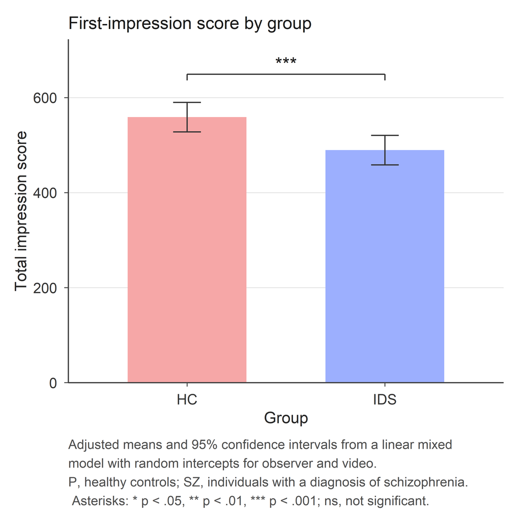

```r
emm_total <- emm_total |>
  mutate(stim_group = factor(stim_group, levels = c("P", "SZ")))

y_top_total <- max(emm_total$upper.CL, na.rm = TRUE) * 1.10

fig_total <- ggplot(emm_total, aes(x = stim_group, y = emmean,
                                   fill = stim_group)) +
  geom_col(width = 0.6, colour = NA, linewidth = 0.3) +
  geom_errorbar(aes(ymin = lower.CL, ymax = upper.CL),
                width = 0.14, linewidth = 0.4, colour = "grey20") +
  scale_fill_manual(values = GROUP_COLOURS, guide = "none") +
  scale_x_discrete(labels = c("P" = "HC", "SZ" = "IDS")) +
  scale_y_continuous(expand = expansion(mult = c(0, 0.10))) +
  labs(title    = "First-impression score by group",
       x        = "Group",
       y        = "Total impression score",
       caption  = paste0(
         "Adjusted means and 95% confidence intervals from a linear mixed\n",
         "model with random intercepts for observer and video.\n",
         "P, healthy controls; SZ, individuals with a diagnosis of schizophrenia.\n ",
         "Asterisks: * p < .05, ** p < .01, *** p < .001; ns, not significant.")) +
  theme_plos()

fig_total <- add_signif_bracket(fig_total, x1 = 1, x2 = 2,
                                y_top = y_top_total,
                                p_value = res_total$p_value)
fig_total
```

```r
save_figure(fig_total, "Fig1_total_impression_score", RESULTS_H1, width = 5, height = 5)
```

```
## Saved: ../../results/H1/Fig1_total_impression_score.tif and ../../results/H1/Fig1_total_impression_score.png
```

**Fig 1. Total first-impression score by group.** Adjusted means and 95 % confidence intervals from a linear mixed model with random intercepts for observer and video.

### 5.1.1 Diagnostics — total impression score

```r
diag_total <- check_lmm_assumptions(m_total)

tryCatch({
  g <- performance::check_model(m_total)
  ggsave(file.path(RESULTS_H1, "diag_lmm_total_score.png"),
         g, width = 10, height = 8, dpi = 200, bg = "white")
}, error = function(e) NULL)
```

```r
diag_total_tab <- fmt_diag_row(diag_total,
                                label_value = "Total impression score",
                                label_name  = "Outcome")
ft_diag_total <- plos_table(
  diag_total_tab,
  title    = "Diagnostic checks for the total first-impression-score linear mixed model (H1).",
  footnote = c(
    paste0("p > .05 indicates the corresponding assumption is supported. ",
           "Tests: Shapiro-Wilk (residual and BLUP normality); ",
           "Breusch-Pagan-type auxiliary regression (homoscedasticity)."),
    paste0("Summary codes - R: residual normality; H: homoscedasticity; ",
           "RE-obs / RE-vid: random-effect normality; ",
           "singular: variance component on the boundary; ",
           "non-conv.: optimiser non-convergence."),
    paste0("Visual diagnostic panel saved as ",
           "results/H1/diag_lmm_total_score.png.")
  )
)
ft_diag_total
```

Diagnostic checks for the total first-impression-score linear mixed model (H1).

| Outcome | Residual normality (Shapiro p) | Homoscedasticity (BP p) | RE obs normality (p) | RE vid normality (p) | Summary |
| --- | --- | --- | --- | --- | --- |
| Total impression score | .372 | .026 | .187 | .090 | R:ok; H:!; RE-obs:ok; RE-vid:ok |

p > .05 indicates the corresponding assumption is supported. Tests: Shapiro-Wilk (residual and BLUP normality); Breusch-Pagan-type auxiliary regression (homoscedasticity).  
Summary codes - R: residual normality; H: homoscedasticity; RE-obs / RE-vid: random-effect normality; singular: variance component on the boundary; non-conv.: optimiser non-convergence.  
Visual diagnostic panel saved as results/H1/diag_lmm_total_score.png.

```r
save_table(ft_diag_total, "table_S2_lmm_total_diagnostics", RESULTS_H1)
```

## 5.2 Item-level analyses

**Purpose.** Examine the effect of group on each of the 10 first-impression items separately. BH-adjusted *p*-values are reported across the ten items.

```r
items_summary <- run_lmm_set(
  data        = data_complete,
  outcomes    = IMPRESSION_ITEMS,
  fixed_term  = "stim_group",
  target_term = "stim_group",
  bh_correction    = TRUE,
  save_diagnostics = FALSE
)

# Standardised mean-difference effect size (Cohen's d, SZ - P) per item
items_d <- map_dfr(IMPRESSION_ITEMS, function(it) {
  m <- fit_lmm(data_complete, it, "stim_group")
  bind_cols(tibble(outcome = it), lmm_cohens_d(m, "stim_group", ref = "P"))
})
items_summary <- left_join(items_summary, items_d, by = "outcome")

items_tab <- items_summary |>
  mutate(
    Item        = pretty_label(outcome),
    `β (95% CI)`= sprintf("%s %s",
                          fmt_num(estimate, 2),
                          fmt_ci(ci_lo, ci_hi, 2)),
    SE          = fmt_num(se, 2),
    df          = fmt_num(df, 1),
    t           = fmt_num(statistic, 2),
    p           = fmt_p(p_value),
    `p (BH)`    = fmt_p(p_value_BH),
    `Cohen's d (95% CI)` = sprintf("%s %s",
                                   fmt_num(d, 2),
                                   fmt_ci(d_lo, d_hi, 2)),
    `R² marg`   = fmt_num(r2_marg, 3),
    `R² cond`   = fmt_num(r2_cond, 3),
    `f²`        = fmt_num(f2, 3)
  ) |>
  select(Item, `β (95% CI)`, SE, df, t, p, `p (BH)`,
         `Cohen's d (95% CI)`, `R² marg`, `R² cond`, `f²`)

ft_items <- plos_table(
  items_tab,
  title    = "Group effect (SZ vs. P) on each first-impression item from linear mixed models (H1).",
  footnote = c(
    paste0("Each row corresponds to a separate LMM: item ~ stim_group + ",
           "(1 | obs_id) + (1 | vid). REML; Satterthwaite df."),
    paste0("β, estimated mean difference (SZ - P); Cohen's d, standardised ",
           "mean difference (SZ - P); p (BH), Benjamini-Hochberg adjusted ",
           "p-value across the 10 items. R² marginal and conditional are ",
           "Nakagawa estimates.")
  )
)
ft_items
```

Group effect (SZ vs. P) on each first-impression item from linear mixed models (H1).

| Item | β (95% CI) | SE | df | t | p | p (BH) | Cohen's d (95% CI) | R² marg | R² cond | f² |
| --- | --- | --- | --- | --- | --- | --- | --- | --- | --- | --- |
| Sympathique | -8.59 [-13.74, -3.43] | 2.63 | 36.7 | -3.27 | .002 | .003 | -0.38 [-0.62, -0.15] | 0.036 | 0.258 | 0.037 |
| Bizarre inversed | -8.00 [-12.18, -3.82] | 2.13 | 34.8 | -3.76 | <.001 | .002 | -0.29 [-0.45, -0.14] | 0.021 | 0.259 | 0.021 |
| Intelligente | -7.15 [-10.90, -3.39] | 1.91 | 34.9 | -3.73 | <.001 | .002 | -0.37 [-0.57, -0.17] | 0.033 | 0.271 | 0.034 |
| Appreciable | -7.43 [-11.91, -2.95] | 2.29 | 35.6 | -3.25 | .003 | .003 | -0.33 [-0.54, -0.13] | 0.027 | 0.281 | 0.028 |
| Confiance | -7.55 [-11.35, -3.76] | 1.94 | 35.5 | -3.90 | <.001 | .002 | -0.35 [-0.53, -0.17] | 0.030 | 0.238 | 0.031 |
| Dominante | 1.54 [-6.61, 9.69] | 4.16 | 37.2 | 0.37 | .713 | .713 | 0.05 [-0.24, 0.34] | 0.001 | 0.282 | 0.001 |
| Conversation | -8.75 [-13.77, -3.72] | 2.56 | 36.4 | -3.41 | .002 | .003 | -0.36 [-0.56, -0.15] | 0.031 | 0.276 | 0.032 |
| Temps | -7.79 [-12.78, -2.79] | 2.55 | 37.1 | -3.06 | .004 | .005 | -0.32 [-0.53, -0.11] | 0.025 | 0.295 | 0.026 |
| Voisin | -7.42 [-11.64, -3.19] | 2.15 | 37.5 | -3.44 | .001 | .003 | -0.31 [-0.49, -0.13] | 0.023 | 0.281 | 0.024 |
| Assis | -8.49 [-13.32, -3.66] | 2.46 | 37.5 | -3.45 | .001 | .003 | -0.34 [-0.53, -0.14] | 0.028 | 0.313 | 0.028 |

Each row corresponds to a separate LMM: item ~ stim_group + (1 | obs_id) + (1 | vid). REML; Satterthwaite df.  
β, estimated mean difference (SZ - P); Cohen's d, standardised mean difference (SZ - P); p (BH), Benjamini-Hochberg adjusted p-value across the 10 items. R² marginal and conditional are Nakagawa estimates.

```r
save_table(ft_items, "table_07_lmm_items", RESULTS_H1)
```

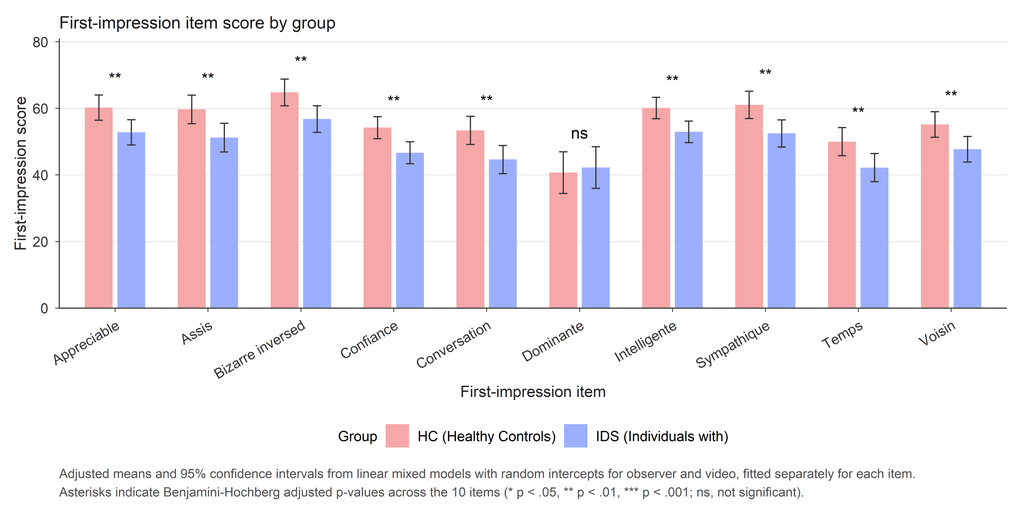

```r
emm_items <- map_dfr(IMPRESSION_ITEMS, function(it) {
  m   <- fit_lmm(data_complete, it, "stim_group")
  emm <- emmeans::emmeans(m, ~ stim_group) |> as.data.frame() |> normalize_emm_ci()
  emm$item <- pretty_label(it)
  emm
}) |> mutate(stim_group = factor(stim_group, levels = c("P", "SZ")))

star_df <- items_summary |>
  transmute(item = pretty_label(outcome), star = p_stars(p_value_BH))

y_pos <- emm_items |>
  group_by(item) |>
  summarise(y_top = max(upper.CL, na.rm = TRUE) * 1.05, .groups = "drop") |>
  left_join(star_df, by = "item")

fig_items <- ggplot(emm_items, aes(x = item, y = emmean, fill = stim_group)) +
  geom_col(position = position_dodge(width = 0.7), width = 0.6,
           colour = NA, linewidth = 0.3) +
  geom_errorbar(aes(ymin = lower.CL, ymax = upper.CL,
                    group = stim_group),
                position = position_dodge(width = 0.7),
                width = 0.18, linewidth = 0.4, colour = "grey20") +
  geom_text(data = y_pos,
            aes(x = item, y = y_top, label = star),
            inherit.aes = FALSE, size = 4, vjust = 0) +
  scale_fill_manual(values = GROUP_COLOURS, name = "Group",
                    labels = c("HC (Healthy Controls)", "IDS (Individuals with)")) +
  scale_x_discrete(labels = c("P" = "HC", "SZ" = "IDS")) +
  scale_y_continuous(expand = expansion(mult = c(0, 0.12))) +
  labs(title   = "First-impression item score by group",
       x       = "First-impression item",
       y       = "First-impression score",
       caption = paste0(
         "Adjusted means and 95% confidence intervals from linear mixed models ",
         "with random intercepts for observer and video, fitted separately for ",
         "each item.\n",
         "Asterisks indicate Benjamini-Hochberg adjusted p-values across the 10 ",
         "items (* p < .05, ** p < .01, *** p < .001; ns, not significant).")) +
  theme_plos() +
  theme(axis.text.x = element_text(angle = 30, hjust = 1))

fig_items
```

```r
save_figure(fig_items, "Fig2_impression_items_by_group", RESULTS_H1,
            width = 10.5, height = 5)
```

```
## Saved: ../../results/H1/Fig2_impression_items_by_group.tif and ../../results/H1/Fig2_impression_items_by_group.png
```

**Fig 2. Adjusted means for each first-impression item by group.** Bars are adjusted means (emmeans) from item-level linear mixed models; error bars are 95 % confidence intervals. Asterisks indicate Benjamini–Hochberg adjusted *p*-values.

### 5.2.1 Diagnostics and random effects — item-level models

```r
items_diag_list <- map(IMPRESSION_ITEMS, function(it) {
  m    <- fit_lmm(data_complete, it, "stim_group")
  diag <- check_lmm_assumptions(m)
  list(item = it, model = m, diag = diag)
})

# 1. Assumption table (10 rows, one per item)
diag_items_tab <- map_dfr(items_diag_list, function(x) {
  fmt_diag_row(x$diag,
               label_value = pretty_label(x$item),
               label_name  = "Item")
})

ft_diag_items <- plos_table(
  diag_items_tab,
  title    = "Diagnostic checks for the 10 item-level linear mixed models (H1).",
  footnote = c(
    paste0("p > .05 indicates the corresponding assumption is supported. ",
           "Tests: Shapiro-Wilk (residual and BLUP normality); ",
           "Breusch-Pagan-type auxiliary regression (homoscedasticity)."),
    paste0("Summary codes - R: residual normality; H: homoscedasticity; ",
           "RE-obs / RE-vid: random-effect normality; ",
           "singular: variance component on the boundary; ",
           "non-conv.: non-convergence.")
  )
)
ft_diag_items
```

Diagnostic checks for the 10 item-level linear mixed models (H1).

| Item | Residual normality (Shapiro p) | Homoscedasticity (BP p) | RE obs normality (p) | RE vid normality (p) | Summary |
| --- | --- | --- | --- | --- | --- |
| Sympathique | .091 | <.001 | .111 | .002 | R:ok; H:!; RE-obs:ok; RE-vid:! |
| Bizarre inversed | <.001 | <.001 | .084 | .406 | R:!; H:!; RE-obs:ok; RE-vid:ok |
| Intelligente | <.001 | .112 | .036 | .572 | R:!; H:ok; RE-obs:!; RE-vid:ok |
| Appreciable | .004 | <.001 | .101 | .009 | R:!; H:!; RE-obs:ok; RE-vid:! |
| Confiance | .004 | .007 | .278 | .238 | R:!; H:!; RE-obs:ok; RE-vid:ok |
| Dominante | <.001 | .006 | .472 | .102 | R:!; H:!; RE-obs:ok; RE-vid:ok |
| Conversation | .120 | .134 | .045 | .860 | R:ok; H:ok; RE-obs:!; RE-vid:ok |
| Temps | .026 | .291 | .129 | .318 | R:!; H:ok; RE-obs:ok; RE-vid:ok |
| Voisin | .059 | .001 | .242 | .091 | R:ok; H:!; RE-obs:ok; RE-vid:ok |
| Assis | .040 | <.001 | .990 | .098 | R:!; H:!; RE-obs:ok; RE-vid:ok |

p > .05 indicates the corresponding assumption is supported. Tests: Shapiro-Wilk (residual and BLUP normality); Breusch-Pagan-type auxiliary regression (homoscedasticity).  
Summary codes - R: residual normality; H: homoscedasticity; RE-obs / RE-vid: random-effect normality; singular: variance component on the boundary; non-conv.: non-convergence.

```r
save_table(ft_diag_items, "table_S3_lmm_items_diagnostics", RESULTS_H1)

# 2. Random-effect variance partition for each item model
re_items_tab <- map_dfr(items_diag_list, function(x) {
  re_proportions_row(x$model, label = pretty_label(x$item),
                     label_name = "Item")
})
ft_re_items <- plos_table(
  re_items_tab,
  title    = "Random-effect variance partition for the 10 item-level models (H1).",
  footnote = c(
    paste0("Each value is the percentage of the residual (unexplained) ",
           "variance captured by the observer random intercept, the video ",
           "random intercept, and the residual."),
    paste0("ICC = (observer + video) / total = proportion of variance ",
           "attributable to the random intercepts.")
  )
)
ft_re_items
```

Random-effect variance partition for the 10 item-level models (H1).

| Item | Observer var (%) | Video var (%) | Residual var (%) | ICC |
| --- | --- | --- | --- | --- |
| Sympathique | 12.7% | 10.4% | 77.0% | 0.230 |
| Bizarre inversed | 21.6% | 2.7% | 75.7% | 0.243 |
| Intelligente | 18.3% | 6.3% | 75.4% | 0.246 |
| Appreciable | 18.8% | 7.2% | 73.9% | 0.261 |
| Confiance | 16.9% | 4.5% | 78.5% | 0.215 |
| Dominante | 10.7% | 17.4% | 71.9% | 0.281 |
| Conversation | 17.8% | 7.5% | 74.7% | 0.253 |
| Temps | 19.8% | 7.9% | 72.3% | 0.277 |
| Voisin | 21.8% | 4.7% | 73.6% | 0.264 |
| Assis | 23.1% | 6.3% | 70.6% | 0.294 |

Each value is the percentage of the residual (unexplained) variance captured by the observer random intercept, the video random intercept, and the residual.  
ICC = (observer + video) / total = proportion of variance attributable to the random intercepts.

```r
save_table(ft_re_items, "table_07b_lmm_items_random_effects", RESULTS_H1)
```

# 6 Movement features: correlations and aggregation (PCA)

**Purpose.** Before aggregating, examine how the four directional movement features — quantity of motion (QoM) of the hands and of the head, each in the horizontal and vertical directions — covary across stimuli. Strong inter-correlations justify reducing them to a single composite, used throughout H2-H4. These construction steps are reported as supplementary material (they are not themselves a hypothesis test).

**Method.** Correlations among the four features at the stimulus level (one value per stimulus). Pearson’s *r* is used when all features are approximately normal (Shapiro-Wilk p > .05), otherwise Spearman’s *ρ*. Reporting Pearson when appropriate keeps this step consistent with the PCA, which decomposes the Pearson correlation matrix.

```r
mov_mat <- data_stimuli |>
  select(all_of(MOVEMENT_VARS)) |>
  filter(if_all(everything(), ~ !is.na(.)))

# Pearson if all features ~normal, otherwise Spearman
shap_p   <- vapply(mov_mat, function(z) shapiro.test(z)$p.value, numeric(1))
cor_meth <- if (all(shap_p > 0.05)) "pearson" else "spearman"
meth_lab <- if (cor_meth == "pearson") "Pearson" else "Spearman"
coef_sym <- if (cor_meth == "pearson") "r" else "rho"
cmat     <- cor(mov_mat, method = cor_meth, use = "complete.obs")

cor_tab <- as.data.frame(round(cmat, 2)) |>
  tibble::rownames_to_column("Feature") |>
  mutate(Feature = unname(MOVEMENT_LABELS[Feature]))
names(cor_tab)[-1] <- unname(MOVEMENT_LABELS[colnames(cmat)])

ft_mov_cor <- plos_table(
  cor_tab,
  title = sprintf("%s correlations among the four directional movement features.",
                  meth_lab),
  footnote = sprintf(paste0("Stimulus-level analysis (n = %d stimuli with ",
                            "complete movement data). %s coefficient (chosen ",
                            "from Shapiro-Wilk normality of all features). ",
                            "QoM, quantity of motion (rate, per second)."),
                     nrow(mov_mat), meth_lab)
)
ft_mov_cor
```

Spearman correlations among the four directional movement features.

| Feature | Hands, horizontal (QoM) | Hands, vertical (QoM) | Head, horizontal (QoM) | Head, vertical (QoM) |
| --- | --- | --- | --- | --- |
| Hands, horizontal (QoM) | 1.00 | 0.96 | 0.68 | 0.69 |
| Hands, vertical (QoM) | 0.96 | 1.00 | 0.70 | 0.71 |
| Head, horizontal (QoM) | 0.68 | 0.70 | 1.00 | 0.65 |
| Head, vertical (QoM) | 0.69 | 0.71 | 0.65 | 1.00 |

Stimulus-level analysis (n = 39 stimuli with complete movement data). Spearman coefficient (chosen from Shapiro-Wilk normality of all features). QoM, quantity of motion (rate, per second).

```r
save_table(ft_mov_cor, "table_08_movement_correlations", RESULTS_SUPPLEMENTARY)
```

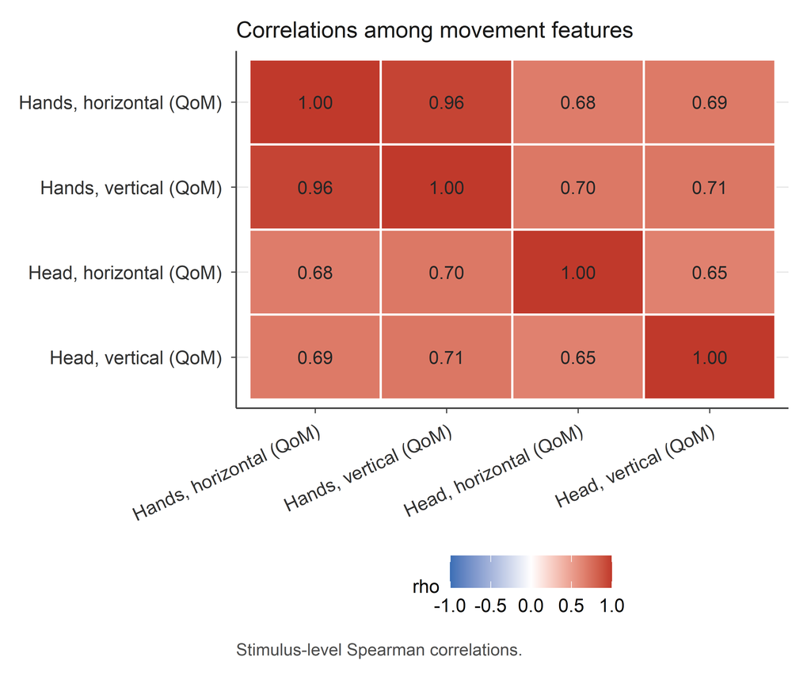

```r
lev <- unname(MOVEMENT_LABELS[MOVEMENT_VARS])
cor_long <- as.data.frame(cmat) |>
  tibble::rownames_to_column("v1") |>
  pivot_longer(-v1, names_to = "v2", values_to = "coef") |>
  mutate(v1 = factor(unname(MOVEMENT_LABELS[v1]), levels = lev),
         v2 = factor(unname(MOVEMENT_LABELS[v2]), levels = rev(lev)))

fig_mov_cor <- ggplot(cor_long, aes(v1, v2, fill = coef)) +
  geom_tile(colour = "white", linewidth = 0.6) +
  geom_text(aes(label = fmt_num(coef, 2)), size = 3.4, colour = "grey15") +
  scale_fill_gradient2(low = "#3b6fb6", mid = "white", high = "#c0392b",
                       midpoint = 0, limits = c(-1, 1), name = coef_sym) +
  labs(x = NULL, y = NULL, title = "Correlations among movement features",
       caption = sprintf("Stimulus-level %s correlations.", meth_lab)) +
  theme_plos() +
  theme(axis.text.x = element_text(angle = 25, hjust = 1))
fig_mov_cor
```

```r
save_figure(fig_mov_cor, "Fig3_movement_correlations", RESULTS_SUPPLEMENTARY,
            width = 6, height = 5)
```

```
## Saved: ../../results/supplementary/Fig3_movement_correlations.tif and ../../results/supplementary/Fig3_movement_correlations.png
```

**Fig 3. Correlations among the four directional movement features.** Stimulus-level correlations (Pearson if features are approximately normal, otherwise Spearman).

## 6.1 Aggregating the movement features (principal component analysis)

**Method.** PCA on the four z-standardised features at the stimulus level (`psych::principal`), reported with sampling-adequacy diagnostics (KMO, Bartlett), eigenvalues, communalities and a scree plot. The dominant component is oriented so that higher = more movement, rescaled to unit SD, and merged onto the evaluation-level data as `move_total_pc1`.

```r
pca_input <- data_stimuli |>
  select(stim_id, all_of(MOVEMENT_VARS)) |>
  filter(if_all(all_of(MOVEMENT_VARS), ~ !is.na(.)))

X <- pca_input |> select(all_of(MOVEMENT_VARS))
R <- cor(X)

# Sampling adequacy
kmo  <- psych::KMO(R)
bart <- psych::cortest.bartlett(R, n = nrow(X))

# Eigenvalues and number of components
eig <- eigen(R, only.values = TRUE)$values

n_keep <- max(1L, sum(eig > 1))

n_parallel <- tryCatch(
  psych::fa.parallel(
    X,
    fa = "pc",
    plot = FALSE,
    n.iter = 100
  )$ncomp,
  error = function(e) NA_integer_
)
```

```
## Parallel analysis suggests that the number of factors =  NA  and the number of components =  1
```

```r
# Keep the original variable name for compatibility
rot <- "none"

# PCA
pca_move <- psych::principal(
  X,
  nfactors = n_keep,
  rotate = rot,
  scores = TRUE
)

# Dominant component, oriented so higher = more movement
ssl <- colSums(unclass(pca_move$loadings)^2)
main_comp <- names(ssl)[which.max(ssl)]

ld_main <- unclass(pca_move$loadings)[, main_comp]
flip <- if (sum(ld_main) < 0) -1 else 1
score_m <- as.numeric(pca_move$scores[, main_comp]) * flip

# Standardised overall movement score
pca_scores <- tibble::tibble(
  stim_id = pca_input$stim_id,
  move_total_pc1 = as.numeric(scale(score_m))
)

data_complete <- data_complete |>
  left_join(pca_scores, by = "stim_id")

data_stimuli <- data_stimuli |>
  left_join(pca_scores, by = "stim_id")

# Table 1: sampling adequacy
suit_tab <- tibble::tibble(
  Statistic = c(
    "KMO (overall MSA)",
    "Bartlett chi-square",
    "Bartlett df",
    "Bartlett p",
    "n (stimuli)"
  ),
  Value = c(
    fmt_num(kmo$MSA, 3),
    fmt_num(bart$chisq, 1),
    as.character(bart$df),
    fmt_p(bart$p.value),
    as.character(nrow(X))
  )
)

ft_suit <- plos_table(
  suit_tab,
  title = "Suitability of the movement features for PCA.",
  footnote = paste0(
    "PCA was based on the Pearson correlation matrix. ",
    "KMO and Bartlett's test are reported as descriptive checks ",
    "of the correlation structure."
  )
)

ft_suit
```

Suitability of the movement features for PCA.

| Statistic | Value |
| --- | --- |
| KMO (overall MSA) | 0.745 |
| Bartlett chi-square | 121.6 |
| Bartlett df | 6 |
| Bartlett p | <.001 |
| n (stimuli) | 39 |

PCA was based on the Pearson correlation matrix. KMO and Bartlett's test are reported as descriptive checks of the correlation structure.

```r
save_table(
  ft_suit,
  "table_09a_movement_pca_suitability",
  RESULTS_SUPPLEMENTARY
)

# Table 2: eigenvalues and variance explained
eig_tab <- tibble::tibble(
  Component = paste0("PC", seq_along(eig)),
  Eigenvalue = fmt_num(eig, 3),
  `% variance` = sprintf("%.1f%%", eig / sum(eig) * 100),
  `Cumulative %` = sprintf("%.1f%%", cumsum(eig) / sum(eig) * 100)
)

ft_eig <- plos_table(
  eig_tab,
  title = "Eigenvalues and variance explained.",
  footnote = sprintf(
    paste0(
      "Components retained using the Kaiser criterion (eigenvalue > 1): %d; ",
      "parallel analysis suggests: %s. Rotation: %s."
    ),
    n_keep,
    ifelse(is.na(n_parallel), "n/a", n_parallel),
    rot
  )
)

ft_eig
```

Eigenvalues and variance explained.

| Component | Eigenvalue | % variance | Cumulative % |
| --- | --- | --- | --- |
| PC1 | 3.043 | 76.1% | 76.1% |
| PC2 | 0.476 | 11.9% | 88.0% |
| PC3 | 0.426 | 10.7% | 98.6% |
| PC4 | 0.054 | 1.4% | 100.0% |

Components retained using the Kaiser criterion (eigenvalue > 1): 1; parallel analysis suggests: 1. Rotation: none.

```r
save_table(
  ft_eig,
  "table_09b_movement_pca_eigenvalues",
  RESULTS_SUPPLEMENTARY
)

# Table 3: loadings and communalities
load_tab <- as.data.frame(
  round(unclass(pca_move$loadings), 3)
) |>
  tibble::rownames_to_column("Feature") |>
  mutate(
    Feature = unname(MOVEMENT_LABELS[Feature]),
    `Communality (h2)` = fmt_num(pca_move$communality, 3)
  )

variance_explained <- eig[seq_len(n_keep)] / sum(eig)

ft_pca <- plos_table(
  load_tab,
  title = "PCA loadings and communalities (four movement features, standardised).",
  footnote = c(
    sprintf(
      "Variance explained: %s.",
      paste(
        sprintf(
          "PC%d = %.1f%%",
          seq_len(n_keep),
          variance_explained * 100
        ),
        collapse = "; "
      )
    ),
    sprintf(
      paste0(
        "Dominant component (%s) was oriented so that higher scores indicate ",
        "more movement and rescaled to unit SD for use as the overall movement score. ",
        "Communalities (h2) indicate the proportion of variance in each feature ",
        "captured by the retained component(s)."
      ),
      main_comp
    )
  )
)

ft_pca
```

PCA loadings and communalities (four movement features, standardised).

| Feature | PC1 | Communality (h2) |
| --- | --- | --- |
| Hands, horizontal (QoM) | 0.924 | 0.854 |
| Hands, vertical (QoM) | 0.941 | 0.886 |
| Head, horizontal (QoM) | 0.802 | 0.642 |
| Head, vertical (QoM) | 0.813 | 0.661 |

Variance explained: PC1 = 76.1%.  
Dominant component (PC1) was oriented so that higher scores indicate more movement and rescaled to unit SD for use as the overall movement score. Communalities (h2) indicate the proportion of variance in each feature captured by the retained component(s).

```r
save_table(
  ft_pca,
  "table_09_movement_pca",
  RESULTS_SUPPLEMENTARY
)

# Export the PC1-augmented datasets
write_csv(
  data_complete,
  file.path(
    RESULTS_SUPPLEMENTARY,
    "data_complete_with_movement_pc1.csv"
  )
)

write_csv(
  data_stimuli,
  file.path(
    RESULTS_SUPPLEMENTARY,
    "data_stimuli_with_movement_pc1.csv"
  )
)
```

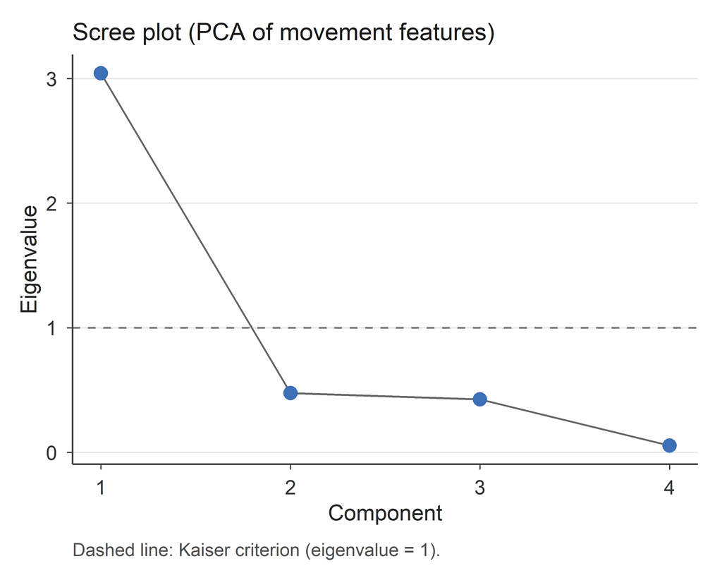

```r
fig_scree <- tibble::tibble(Component = seq_along(eig), Eigenvalue = eig) |>
  ggplot(aes(Component, Eigenvalue)) +
  geom_hline(yintercept = 1, linetype = "dashed", colour = "grey50") +
  geom_line(colour = "grey40") +
  geom_point(size = 2.8, colour = "#3b6fb6") +
  scale_x_continuous(breaks = seq_along(eig)) +
  labs(title = "Scree plot (PCA of movement features)",
       x = "Component", y = "Eigenvalue",
       caption = "Dashed line: Kaiser criterion (eigenvalue = 1).") +
  theme_plos()
fig_scree
```

```r
save_figure(fig_scree, "FigS1_pca_scree", RESULTS_SUPPLEMENTARY, width = 5, height = 4)
```

```
## Saved: ../../results/supplementary/FigS1_pca_scree.tif and ../../results/supplementary/FigS1_pca_scree.png
```

A single component was retained, so no rotation applies; it captures one dimension of overall body movement, on which the four features load together.

# 7 H2 - Does diagnostic group predict overall movement?

**Purpose.** Describe the four movement features by group and formally test the group difference on the aggregate movement score (overall PCA component) at the stimulus level.

```r
mov_summary <- map_dfr(MOVEMENT_VARS, function(v) {
  d <- data_stimuli |> filter(!is.na(.data[[v]]))
  by_group <- d |>
    group_by(stim_group) |>
    summarise(n = dplyr::n(), m = mean(.data[[v]]), s = sd(.data[[v]]),
              med = median(.data[[v]]), q1 = quantile(.data[[v]], .25),
              q3 = quantile(.data[[v]], .75),
              shap = if (dplyr::n() >= 3) shapiro.test(.data[[v]])$p.value else NA_real_,
              .groups = "drop")
  normal_p <- all(by_group$shap > 0.05, na.rm = TRUE)
  p_row <- by_group |> filter(stim_group == "P")
  s_row <- by_group |> filter(stim_group == "SZ")
  tibble(
    Feature      = unname(MOVEMENT_LABELS[v]),
    `P n`        = p_row$n,
    `P summary`  = if (normal_p) fmt_msd(p_row$m, p_row$s, 3)
                   else sprintf("%s [%s, %s]", fmt_num(p_row$med,3), fmt_num(p_row$q1,3), fmt_num(p_row$q3,3)),
    `SZ n`       = s_row$n,
    `SZ summary` = if (normal_p) fmt_msd(s_row$m, s_row$s, 3)
                   else sprintf("%s [%s, %s]", fmt_num(s_row$med,3), fmt_num(s_row$q1,3), fmt_num(s_row$q3,3)),
    Distribution = if (normal_p) "Normal" else "Non-normal"
  )
})
ft_mov_descr <- plos_table(
  mov_summary,
  title    = "Stimulus-level descriptive statistics for the four movement features, by group.",
  footnote = paste0("Mean (SD) for approximately normal variables; median ",
                    "[Q1, Q3] otherwise (Shapiro-Wilk within group, alpha = 0.05). ",
                    "QoM normalised by video duration (rate, per second).")
)
ft_mov_descr
```

Stimulus-level descriptive statistics for the four movement features, by group.

| Feature | P n | P summary | SZ n | SZ summary | Distribution |
| --- | --- | --- | --- | --- | --- |
| Hands, horizontal (QoM) | 20 | 1.398 (0.944) | 19 | 0.706 (0.506) | Normal |
| Hands, vertical (QoM) | 20 | 1.468 (0.920) | 19 | 0.815 (0.609) | Normal |
| Head, horizontal (QoM) | 20 | 0.419 [0.251, 0.496] | 20 | 0.132 [0.099, 0.310] | Non-normal |
| Head, vertical (QoM) | 20 | 0.491 (0.245) | 20 | 0.411 (0.262) | Normal |

Mean (SD) for approximately normal variables; median [Q1, Q3] otherwise (Shapiro-Wilk within group, alpha = 0.05). QoM normalised by video duration (rate, per second).

```r
save_table(ft_mov_descr, "table_10_movement_descriptives", RESULTS_DESCRIPTIVE)

# Group difference on the aggregate movement score (stimulus level) - this is
# the H2 test.
gt <- auto_group_test(data_stimuli, "move_total_pc1", "stim_group")
mov_grp_tab <- tibble::tibble(
  Comparison    = "P vs SZ",
  `M (SD), P`   = fmt_msd(gt$mean_g1, gt$sd_g1, 2),
  `M (SD), SZ`  = fmt_msd(gt$mean_g2, gt$sd_g2, 2),
  Test          = gt$test,
  Statistic     = fmt_num(gt$statistic, 2),
  df            = ifelse(is.na(gt$df), "—", fmt_num(gt$df, 1)),
  p             = fmt_p(gt$p_value),
  `Effect size` = sprintf("%s = %s %s", gt$es_name, fmt_num(gt$es, 2),
                          fmt_ci(gt$es_ci_lo, gt$es_ci_hi, 2))
)
ft_mov_grp <- plos_table(
  mov_grp_tab,
  title    = "Group difference on the aggregate movement score (overall PCA component) (H2).",
  footnote = c(
    paste0("Stimulus-level test (one value per stimulus). The aggregate score ",
           "is standardised to unit SD; a positive effect size denotes more ",
           "movement in P than in SZ."),
    "Test auto-selected from normality (Shapiro-Wilk) and variance homogeneity (Levene)."
  )
)
ft_mov_grp
```

Group difference on the aggregate movement score (overall PCA component) (H2).

| Comparison | M (SD), P | M (SD), SZ | Test | Statistic | df | p | Effect size |
| --- | --- | --- | --- | --- | --- | --- | --- |
| P vs SZ | 0.39 (1.03) | -0.41 (0.80) | Student t-test | 2.71 | 37.0 | .010 | Cohen's d = 0.87 [0.21, 1.52] |

Stimulus-level test (one value per stimulus). The aggregate score is standardised to unit SD; a positive effect size denotes more movement in P than in SZ.  
Test auto-selected from normality (Shapiro-Wilk) and variance homogeneity (Levene).

```r
save_table(ft_mov_grp, "table_11_movement_group_difference", RESULTS_H2)
```

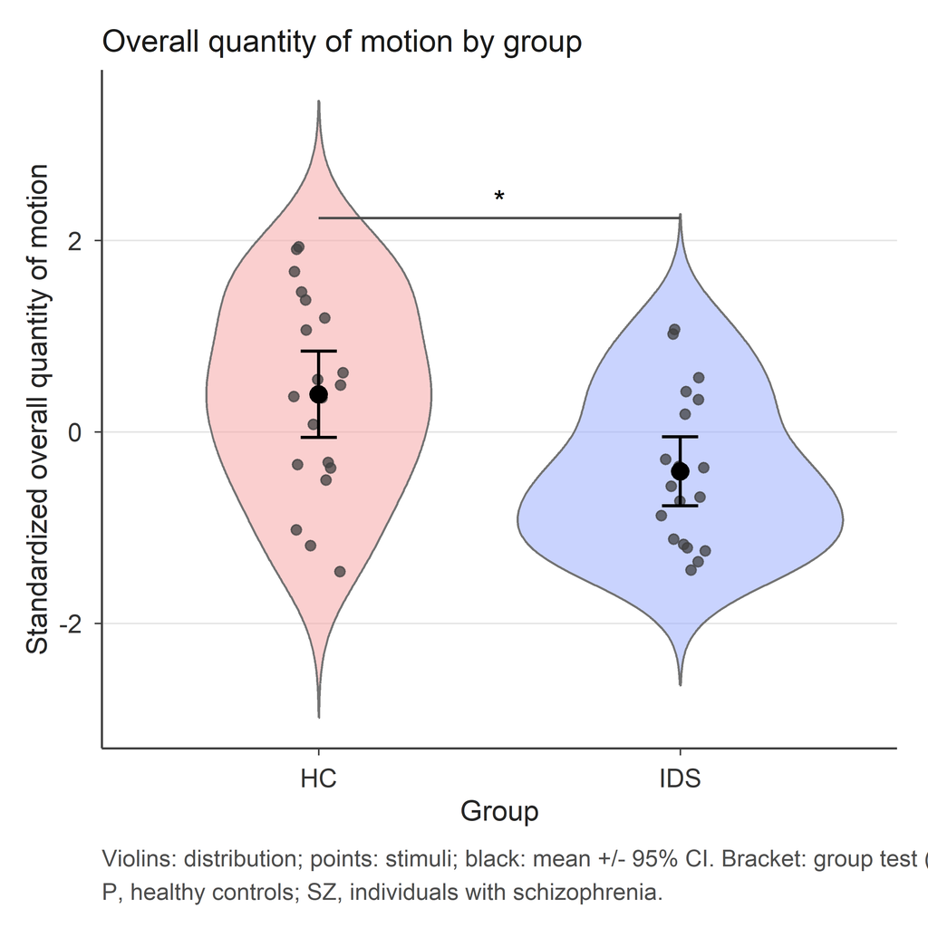

```r
dd_mov <- data_stimuli |>
  filter(!is.na(move_total_pc1)) |>
  mutate(stim_group = factor(stim_group, levels = c("P", "SZ")))

# Mean +/- 95% CI per group
summ_mov <- dd_mov |>
  group_by(stim_group) |>
  summarise(m = mean(move_total_pc1),
            se = sd(move_total_pc1) / sqrt(dplyr::n()),
            lo = m - 1.96 * se, hi = m + 1.96 * se, .groups = "drop")

# Significance marker from the group test computed above (gt)
gp_p <- gt$p_value
star <- if (gp_p < .001) "***" else if (gp_p < .01) "**" else
        if (gp_p < .05) "*"   else "ns"
ybar <- max(dd_mov$move_total_pc1, na.rm = TRUE) + 0.30

fig_mov_grp <- ggplot(dd_mov, aes(stim_group, move_total_pc1, fill = stim_group)) +
  geom_violin(width = 0.9, alpha = 0.55, colour = "grey45",
              linewidth = 0.4, trim = FALSE) +
  geom_jitter(width = 0.07, height = 0, size = 1.6, alpha = 0.75,
              colour = "grey25") +
  geom_errorbar(data = summ_mov,
                aes(x = stim_group, ymin = lo, ymax = hi),
                width = 0.10, linewidth = 0.6, colour = "black",
                inherit.aes = FALSE) +
  geom_point(data = summ_mov, aes(x = stim_group, y = m),
             size = 2.8, colour = "black", inherit.aes = FALSE) +
  annotate("segment", x = 1, xend = 2, y = ybar, yend = ybar, colour = "grey30") +
  annotate("text", x = 1.5, y = ybar + 0.18, label = star, size = 4.2) +
  scale_fill_manual(values = GROUP_COLOURS, guide = "none") +
  scale_x_discrete(labels = c("P" = "HC", "SZ" = "IDS")) +
  labs(title = "Overall quantity of motion by group",
       x = "Group", y = "Standardized overall quantity of motion",
       caption = paste0("Violins: distribution; points: stimuli; black: ",
                        "mean +/- 95% CI. Bracket: group test (", star, ").\n",
                        "P, healthy controls; SZ, individuals with schizophrenia.")) +
  theme_plos()
fig_mov_grp
```

```r
save_figure(fig_mov_grp, "Fig4_movement_by_group", RESULTS_H2, width = 5, height = 5)
```

```
## Saved: ../../results/H2/Fig4_movement_by_group.tif and ../../results/H2/Fig4_movement_by_group.png
```

**Fig 4. Overall body movement by group.** Stimulus-level aggregate movement score (overall PCA component). Violins show the distribution, points the individual stimuli, and the black marker the mean +/- 95% CI; the bracket reports the group test.

# 8 H3 - Does overall movement predict first impressions?

**Purpose.** Test whether overall body movement (the aggregate PCA component) predicts the total first-impression score, with the same observer × video random structure.

**Variables.** Outcome: `imp_total_score`. Fixed effect: `move_total_pc1` (unit-SD overall movement score). Random intercepts: observer (`obs_id`) and video (`vid`).

```r
m_pc1 <- fit_lmm(data_complete, "imp_total_score", "move_total_pc1")

pc1_fixed <- lmm_fixed_table(m_pc1, drop_intercept = TRUE)

r2_pc1  <- tryCatch(performance::r2(m_pc1), error = function(e) NULL)
r2m_pc1 <- if (!is.null(r2_pc1)) as.numeric(r2_pc1$R2_marginal)    else NA_real_
r2c_pc1 <- if (!is.null(r2_pc1)) as.numeric(r2_pc1$R2_conditional) else NA_real_

# Video-level R2: proportion of BETWEEN-VIDEO variance explained by movement
# (Snijders & Bosker level-2 R2: reduction in the video variance vs a model
# without movement). More informative than the marginal R2 for a video-level
# predictor, since the marginal R2 is diluted by observer + residual variance.
vid_var <- function(m) {
  vc <- as.data.frame(lme4::VarCorr(m)); vc$vcov[vc$grp == "vid"]
}
m_null_mov <- fit_lmm(data_complete, "imp_total_score", "1")   # no movement
r2_video   <- 1 - vid_var(m_pc1) / vid_var(m_null_mov)

pc1_lmm_tab <- pc1_fixed |>
  mutate(
    Predictor    = "Overall movement (PCA)",
    `β (95% CI)` = sprintf("%s %s", fmt_num(estimate, 3),
                           fmt_ci(ci_lo, ci_hi, 3)),
    SE           = fmt_num(se, 3),
    df           = fmt_num(df, 1),
    t            = fmt_num(statistic, 2),
    p            = fmt_p(p_value)
  ) |>
  select(Predictor, `β (95% CI)`, SE, df, t, p)

ft_lmm_pc1 <- plos_table(
  pc1_lmm_tab,
  title = "Linear mixed model predicting the total first-impression score from overall movement (PCA component) (H3).",
  footnote = c(
    paste0("Model: imp_total_score ~ move_total_pc1 + (1 | obs_id) + ",
           "(1 | vid). REML; Satterthwaite df."),
    sprintf(paste0("Whole-model effect sizes: marginal R2 = %s (movement), ",
                   "conditional R2 = %s (PC1 + random effects); f2 = %s."),
            fmt_num(r2m_pc1, 3), fmt_num(r2c_pc1, 3),
            fmt_num(if (!is.na(r2m_pc1) && r2m_pc1 < 1) r2m_pc1/(1-r2m_pc1) else NA_real_, 3)),
    sprintf(paste0("Video-level R2 = %s (proportion of between-video variance ",
                   "explained by movement; Snijders & Bosker level-2 R2)."),
            fmt_num(r2_video, 3)),
    paste0("PC1 is standardised to unit SD; β is the change in total ",
           "impression score per 1 SD increase in overall body movement."),
    model_info_line(m_pc1)
  )
)
ft_lmm_pc1
```

Linear mixed model predicting the total first-impression score from overall movement (PCA component) (H3).

| Predictor | β (95% CI) | SE | df | t | p |
| --- | --- | --- | --- | --- | --- |
| Overall movement (PCA) | 53.063 [38.266, 67.860] | 7.550 | 37.3 | 7.03 | <.001 |

Model: imp_total_score ~ move_total_pc1 + (1 | obs_id) + (1 | vid). REML; Satterthwaite df.  
Whole-model effect sizes: marginal R2 = 0.100 (movement), conditional R2 = 0.357 (PC1 + random effects); f2 = 0.111.  
Video-level R2 = 0.663 (proportion of between-video variance explained by movement; Snijders & Bosker level-2 R2).  
PC1 is standardised to unit SD; β is the change in total impression score per 1 SD increase in overall body movement.  
N = 879 evaluations from 91 observers and 39 videos. AIC = 11242.4; BIC = 11266.3; REML deviance = 11232.4.

```r
save_table(ft_lmm_pc1, "table_12_lmm_movement_pc1", RESULTS_H3)

# ---- Random-effect variance partition --------------------------------------
ft_re_pc1 <- fmt_re_table(
  m_pc1,
  title    = "Random-effect variance partition for the PC1 movement model (H3).",
  footnote = "Random intercepts: observer (obs_id) and video (vid)."
)
ft_re_pc1
```

Random-effect variance partition for the PC1 movement model (H3).

| Random component | Variance | SD | % of residual+random variance |
| --- | --- | --- | --- |
| obs_id (random intercept) | 5666.924 | 75.279 | 23.1% |
| vid (random intercept) | 1335.478 | 36.544 | 5.5% |
| Residual (within-evaluation) | 17477.596 | 132.203 | 71.4% |

Random intercepts: observer (obs_id) and video (vid).  
ICC = 0.286: proportion of the residual (unexplained) variance captured jointly by the observer and video random intercepts.  
Marginal R2 = 0.100 (fixed effects); conditional R2 = 0.357 (fixed + random). The random structure adds 0.257 of explained variance beyond the fixed effects.

```r
save_table(ft_re_pc1, "table_12b_lmm_movement_pc1_random_effects", RESULTS_H3)
```

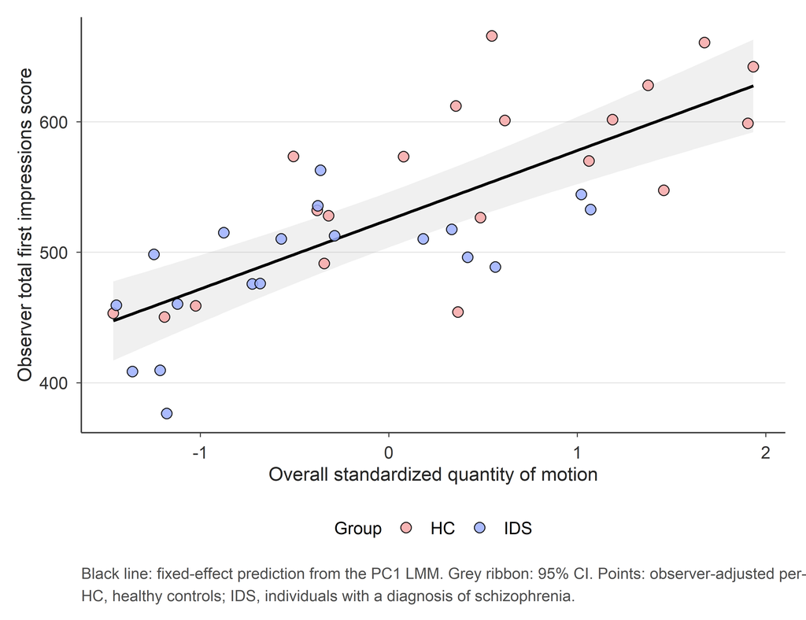

```r
# Fixed-effect prediction line over the PC1 range
rng_pc1 <- range(data_complete$move_total_pc1, na.rm = TRUE)
x_seq   <- seq(rng_pc1[1], rng_pc1[2], length.out = 100)
newdat  <- tibble::tibble(move_total_pc1 = x_seq)

Xp    <- model.matrix(~ move_total_pc1, newdat)
beta  <- lme4::fixef(m_pc1)
Vp    <- as.matrix(vcov(m_pc1))
predp <- as.numeric(Xp %*% beta)
sep   <- sqrt(diag(Xp %*% Vp %*% t(Xp)))
pred_pc1 <- tibble::tibble(x = x_seq, y = predp,
                           lo = predp - 1.96 * sep, hi = predp + 1.96 * sep)

# Observer-BLUP-adjusted per-video means (purged of observer tendencies)
re_obs_pc1 <- lme4::ranef(m_pc1)$obs_id |>
  tibble::rownames_to_column("obs_id") |>
  mutate(obs_id = as.character(obs_id)) |>
  rename(u_obs = `(Intercept)`)

pts_pc1 <- data_complete |>
  mutate(obs_id     = as.character(obs_id),
         stim_group = factor(stim_group, levels = c("P", "SZ"))) |>
  filter(!is.na(move_total_pc1), !is.na(imp_total_score), !is.na(obs_id)) |>
  left_join(re_obs_pc1, by = "obs_id") |>
  mutate(y_adj = imp_total_score - u_obs) |>
  group_by(stim_id, stim_group) |>
  summarise(x = dplyr::first(move_total_pc1),
            imp_adj = mean(y_adj, na.rm = TRUE), .groups = "drop")

fig_pc1 <- ggplot() +
  geom_ribbon(data = pred_pc1, aes(x = x, ymin = lo, ymax = hi),
              alpha = 0.15, fill = "grey60") +
  geom_line(data = pred_pc1, aes(x = x, y = y),
            linewidth = 0.8, colour = "black") +
  geom_point(data = pts_pc1, aes(x = x, y = imp_adj, fill = stim_group),
             shape = 21, size = 2.6, colour = "black", alpha = 0.85) +
  scale_fill_manual(
    values = GROUP_COLOURS,
    name = "Group",
    breaks = c("P", "SZ"),
    labels = c("HC", "IDS")
  ) +
  labs(x = "Overall standardized quantity of motion",
       y = "Observer total first impressions score",
       caption = paste0(
         "Black line: fixed-effect prediction from the PC1 LMM. ",
         "Grey ribbon: 95% CI. Points: observer-adjusted per-video means.\n",
         "HC, healthy controls; IDS, individuals with a diagnosis of schizophrenia.")) +
  theme_plos()
fig_pc1
```

```r
save_figure(fig_pc1, "Fig5_movement_predicts_impression", RESULTS_H3,
            width = 6.5, height = 5)
```

```
## Saved: ../../results/H3/Fig5_movement_predicts_impression.tif and ../../results/H3/Fig5_movement_predicts_impression.png
```

**Fig 5. Total first-impression score predicted by overall movement (overall movement).** Black line is the fixed-effect prediction from the LMM (grey ribbon: 95 % CI); points are observer-adjusted per-video means.

### 8.0.1 Diagnostics — PC1 model

```r
diag_pc1 <- check_lmm_assumptions(m_pc1)

tryCatch({
  g <- performance::check_model(m_pc1)
  ggsave(file.path(RESULTS_H3, "diag_lmm_movement_pc1.png"),
         g, width = 10, height = 8, dpi = 200, bg = "white")
}, error = function(e) NULL)
```

```r
diag_pc1_tab <- fmt_diag_row(diag_pc1,
                             label_value = "PC1 movement model",
                             label_name  = "Model")
ft_diag_pc1 <- plos_table(
  diag_pc1_tab,
  title    = "Diagnostic checks for the PC1 movement-based first-impression model (H3).",
  footnote = c(
    paste0("p > .05 indicates the corresponding assumption is supported. ",
           "Tests: Shapiro-Wilk (residual and BLUP normality); ",
           "Breusch-Pagan-type auxiliary regression (homoscedasticity)."),
    paste0("Summary codes - R: residual normality; H: homoscedasticity; ",
           "RE-obs / RE-vid: random-effect normality; ",
           "singular / non-conv.: boundary or convergence flags. ",
           "Visual panel: results/H3/diag_lmm_movement_pc1.png.")
  )
)
ft_diag_pc1
```

Diagnostic checks for the PC1 movement-based first-impression model (H3).

| Model | Residual normality (Shapiro p) | Homoscedasticity (BP p) | RE obs normality (p) | RE vid normality (p) | Summary |
| --- | --- | --- | --- | --- | --- |
| PC1 movement model | .390 | .061 | .297 | .932 | R:ok; H:ok; RE-obs:ok; RE-vid:ok |

p > .05 indicates the corresponding assumption is supported. Tests: Shapiro-Wilk (residual and BLUP normality); Breusch-Pagan-type auxiliary regression (homoscedasticity).  
Summary codes - R: residual normality; H: homoscedasticity; RE-obs / RE-vid: random-effect normality; singular / non-conv.: boundary or convergence flags. Visual panel: results/H3/diag_lmm_movement_pc1.png.

```r
save_table(ft_diag_pc1, "table_S4_lmm_movement_diagnostics", RESULTS_H3)
```

# 9 H4 - Group and movement jointly

**Purpose.** This is the first-impressions model of the total score (H1) with aggregate movement **added** as a second fixed effect. It answers two questions at once: (i) does movement predict impressions *after adjusting for diagnostic group*, and (ii) does the group difference *shrink* once movement is taken into account — a mediation-style question (movement as a candidate behavioural pathway for the group difference).

**Variables.** Outcome: `imp_total_score`. Fixed effects: `stim_group` (SZ vs P) **and** `move_total_pc1` (unit-SD aggregate movement). Random intercepts: observer (`obs_id`) and video (`vid`).

**Caveat.** Group and movement are both stimulus-level and correlated (movement discriminates the groups), so they are partially collinear; the individual coefficients are therefore estimated with less precision (VIF reported below), and the attenuation is descriptive, not a formal mediation test.

```r
m_grp_pc1 <- fit_lmm(data_complete, "imp_total_score",
                     "stim_group + move_total_pc1")

gp_fixed <- lmm_fixed_table(m_grp_pc1, drop_intercept = TRUE)

r2_gp  <- tryCatch(performance::r2(m_grp_pc1), error = function(e) NULL)
r2m_gp <- if (!is.null(r2_gp)) as.numeric(r2_gp$R2_marginal)    else NA_real_
r2c_gp <- if (!is.null(r2_gp)) as.numeric(r2_gp$R2_conditional) else NA_real_

label_term <- function(x) dplyr::case_when(
  grepl("move_total_pc1", x) ~ "Overall movement (PCA)",
  grepl("stim_group",     x) ~ "Group (SZ vs P)",
  TRUE ~ x)

gp_tab <- gp_fixed |>
  mutate(
    Predictor    = label_term(term),
    `β (95% CI)` = sprintf("%s %s", fmt_num(estimate, 2),
                           fmt_ci(ci_lo, ci_hi, 2)),
    SE           = fmt_num(se, 2),
    df           = fmt_num(df, 1),
    t            = fmt_num(statistic, 2),
    p            = fmt_p(p_value)
  ) |>
  select(Predictor, `β (95% CI)`, SE, df, t, p)

ft_lmm_gp <- plos_table(
  gp_tab,
  title = "Linear mixed model predicting the total first-impression score from group and overall movement jointly (H4).",
  footnote = c(
    paste0("Model: imp_total_score ~ stim_group + move_total_pc1 + ",
           "(1 | obs_id) + (1 | vid). REML; Satterthwaite df. β for group is ",
           "the SZ - P difference adjusting for movement; β for PC1 is per ",
           "1 SD of movement adjusting for group."),
    sprintf(paste0("Whole-model effect sizes: marginal R2 = %s; ",
                   "conditional R2 = %s; f2 = %s."),
            fmt_num(r2m_gp, 3), fmt_num(r2c_gp, 3),
            fmt_num(if (!is.na(r2m_gp) && r2m_gp < 1) r2m_gp/(1-r2m_gp) else NA_real_, 3)),
    model_info_line(m_grp_pc1)
  )
)
ft_lmm_gp
```

Linear mixed model predicting the total first-impression score from group and overall movement jointly (H4).

| Predictor | β (95% CI) | SE | df | t | p |
| --- | --- | --- | --- | --- | --- |
| Group (SZ vs P) | -33.16 [-63.35, -2.98] | 15.40 | 34.5 | -2.15 | .038 |
| Overall movement (PCA) | 46.07 [30.63, 61.51] | 7.88 | 36.0 | 5.85 | <.001 |

Model: imp_total_score ~ stim_group + move_total_pc1 + (1 | obs_id) + (1 | vid). REML; Satterthwaite df. β for group is the SZ - P difference adjusting for movement; β for PC1 is per 1 SD of movement adjusting for group.  
Whole-model effect sizes: marginal R2 = 0.108; conditional R2 = 0.357; f2 = 0.121.  
N = 879 evaluations from 91 observers and 39 videos. AIC = 11232.7; BIC = 11261.4; REML deviance = 11220.7.

```r
save_table(ft_lmm_gp, "table_13_lmm_group_movement", RESULTS_H4)

# ---- Attenuation of the group effect when movement is added ----------------
g_alone <- extract_lmm_results(m_total,   "stim_group")
g_adj   <- extract_lmm_results(m_grp_pc1, "stim_group")
atten_pct <- if (!is.na(g_alone$estimate) && g_alone$estimate != 0)
  (1 - g_adj$estimate / g_alone$estimate) * 100 else NA_real_

atten_tab <- tibble::tibble(
  `Group effect (SZ - P)` = c("Unadjusted (group only, H1)",
                              "Adjusted for movement (H4)",
                              "Attenuation of |β|"),
  `β (95% CI)` = c(
    sprintf("%s %s", fmt_num(g_alone$estimate, 2),
            fmt_ci(g_alone$ci_lo, g_alone$ci_hi, 2)),
    sprintf("%s %s", fmt_num(g_adj$estimate, 2),
            fmt_ci(g_adj$ci_lo, g_adj$ci_hi, 2)),
    sprintf("%s%%", fmt_num(atten_pct, 1))),
  p = c(fmt_p(g_alone$p_value), fmt_p(g_adj$p_value), "")
)
ft_atten <- plos_table(
  atten_tab,
  title = "Attenuation of the group difference in first impressions after adjusting for aggregate movement (H4).",
  footnote = paste0(
    "A reduction in the magnitude of the group coefficient when movement is ",
    "added is consistent with movement partly accounting for (mediating) the ",
    "group difference. Descriptive comparison, not a formal mediation test; ",
    "group and movement are correlated at the stimulus level (see below).")
)
ft_atten
```

Attenuation of the group difference in first impressions after adjusting for aggregate movement (H4).

| Group effect (SZ - P) | β (95% CI) | p |
| --- | --- | --- |
| Unadjusted (group only, H1) | -69.55 [-106.53, -32.57] | <.001 |
| Adjusted for movement (H4) | -33.16 [-63.35, -2.98] | .038 |
| Attenuation of \|β\| | 52.3% |  |

A reduction in the magnitude of the group coefficient when movement is added is consistent with movement partly accounting for (mediating) the group difference. Descriptive comparison, not a formal mediation test; group and movement are correlated at the stimulus level (see below).

```r
save_table(ft_atten, "table_13b_group_effect_attenuation", RESULTS_H4)

# ---- Collinearity between group and movement (stimulus level) --------------
g_num  <- as.integer(factor(data_complete$stim_group)) - 1L   # P = 0, SZ = 1
r_gp   <- cor(g_num, data_complete$move_total_pc1, use = "complete.obs")
vif_gp <- 1 / (1 - r_gp^2)
collin_gp_tab <- tibble::tibble(
  Quantity = c("Point-biserial r (group vs PC1)",
               "Variance inflation factor (VIF)",
               "SE inflation factor (sqrt of VIF)"),
  Value    = c(fmt_num(r_gp, 3), fmt_num(vif_gp, 2), fmt_num(sqrt(vif_gp), 2))
)
ft_collin_gp <- plos_table(
  collin_gp_tab,
  title = "Collinearity between group and aggregate movement in the joint model (H4).",
  footnote = paste0(
    "Group and movement are correlated because movement discriminates the ",
    "groups. The VIF quantifies how much this inflates the standard errors ",
    "of the two stimulus-level predictors and tempers the interpretation of ",
    "their individual coefficients.")
)
ft_collin_gp
```

Collinearity between group and aggregate movement in the joint model (H4).

| Quantity | Value |
| --- | --- |
| Point-biserial r (group vs PC1) | -0.408 |
| Variance inflation factor (VIF) | 1.20 |
| SE inflation factor (sqrt of VIF) | 1.10 |

Group and movement are correlated because movement discriminates the groups. The VIF quantifies how much this inflates the standard errors of the two stimulus-level predictors and tempers the interpretation of their individual coefficients.

```r
save_table(ft_collin_gp, "table_13c_group_movement_collinearity", RESULTS_H4)

# ---- Random-effect variance partition --------------------------------------
ft_re_gp <- fmt_re_table(
  m_grp_pc1,
  title    = "Random-effect variance partition for the group + movement model (H4).",
  footnote = "Random intercepts: observer (obs_id) and video (vid)."
)
ft_re_gp
```

Random-effect variance partition for the group + movement model (H4).

| Random component | Variance | SD | % of residual+random variance |
| --- | --- | --- | --- |
| obs_id (random intercept) | 5653.925 | 75.193 | 23.3% |
| vid (random intercept) | 1126.708 | 33.566 | 4.6% |
| Residual (within-evaluation) | 17487.607 | 132.241 | 72.1% |

Random intercepts: observer (obs_id) and video (vid).  
ICC = 0.279: proportion of the residual (unexplained) variance captured jointly by the observer and video random intercepts.  
Marginal R2 = 0.108 (fixed effects); conditional R2 = 0.357 (fixed + random). The random structure adds 0.249 of explained variance beyond the fixed effects.

```r
save_table(ft_re_gp, "table_13d_lmm_group_movement_random_effects", RESULTS_H4)
```

[figure not shown]

```r
pc1_row <- grepl("move_total_pc1", gp_fixed$term)
forest_df <- tibble::tibble(
  label = factor(
    c("Group (SZ - P)\nunadjusted",
      "Group (SZ - P)\nadjusting for movement",
      "Movement\nadjusting for group"),
    levels = c("Movement\nadjusting for group",
               "Group (SZ - P)\nadjusting for movement",
               "Group (SZ - P)\nunadjusted")),
  est = c(g_alone$estimate, g_adj$estimate, gp_fixed$estimate[pc1_row]),
  lo  = c(g_alone$ci_lo,    g_adj$ci_lo,    gp_fixed$ci_lo[pc1_row]),
  hi  = c(g_alone$ci_hi,    g_adj$ci_hi,    gp_fixed$ci_hi[pc1_row]),
  kind = c("Group", "Group", "Movement")
)

fig_forest <- ggplot(forest_df, aes(x = est, y = label, colour = kind)) +
  geom_vline(xintercept = 0, linetype = "dashed", colour = "grey50") +
  geom_pointrange(aes(xmin = lo, xmax = hi), linewidth = 0.7, size = 0.6) +
  scale_colour_manual(values = c(Group = GROUP_COLOURS[["SZ"]],
                                 Movement = "grey25"), guide = "none") +
  labs(x = "Effect on total first-impression score (points, 95% CI)",
       y = NULL,
       caption = paste0(
         "Movement effect adjusting for group (top); group effect with and ",
         "without adjustment for movement (middle, bottom).\n",
         "A shift of the group estimate toward zero indicates attenuation.")) +
  theme_plos()
fig_forest
```

```r
save_figure(fig_forest, "Fig6_group_movement_forest", RESULTS_H4, width = 7, height = 3)
```

```
## Saved: ../../results/H4/Fig6_group_movement_forest.tif and ../../results/H4/Fig6_group_movement_forest.png
```

**Fig 6. Group and movement effects on first impressions.** Point estimates with 95 % CIs for the group difference (unadjusted and adjusted for movement) and for movement (adjusted for group). Movement of the group estimate toward zero indicates attenuation.

### 9.0.1 Diagnostics — group + movement model

```r
diag_gp <- check_lmm_assumptions(m_grp_pc1)

tryCatch({
  g <- performance::check_model(m_grp_pc1)
  ggsave(file.path(RESULTS_H4, "diag_lmm_group_movement.png"),
         g, width = 10, height = 8, dpi = 200, bg = "white")
}, error = function(e) NULL)
```

```r
diag_gp_tab <- fmt_diag_row(diag_gp, label_value = "Group + movement model",
                            label_name = "Model")
ft_diag_gp <- plos_table(
  diag_gp_tab,
  title    = "Diagnostic checks for the group + movement first-impression model (H4).",
  footnote = c(
    paste0("p > .05 indicates the corresponding assumption is supported. ",
           "Tests: Shapiro-Wilk (residual and BLUP normality); ",
           "Breusch-Pagan-type auxiliary regression (homoscedasticity)."),
    "Visual panel: results/H4/diag_lmm_group_movement.png."
  )
)
ft_diag_gp
```

Diagnostic checks for the group + movement first-impression model (H4).

| Model | Residual normality (Shapiro p) | Homoscedasticity (BP p) | RE obs normality (p) | RE vid normality (p) | Summary |
| --- | --- | --- | --- | --- | --- |
| Group + movement model | .371 | .045 | .300 | .970 | R:ok; H:!; RE-obs:ok; RE-vid:ok |

p > .05 indicates the corresponding assumption is supported. Tests: Shapiro-Wilk (residual and BLUP normality); Breusch-Pagan-type auxiliary regression (homoscedasticity).  
Visual panel: results/H4/diag_lmm_group_movement.png.

```r
save_table(ft_diag_gp, "table_S5_lmm_group_movement_diagnostics", RESULTS_H4)
```

# 10 Robustness: cluster bootstrap

**Purpose.** The total-score model and most item models showed mild heteroscedasticity. To verify that the key conclusions do not depend on the residual-variance assumptions, the principal fixed effects of H1, H3 and H4 are re-estimated with a **cluster bootstrap**: whole stimuli (videos) are resampled with replacement and each model is refitted, giving robust standard errors, percentile 95 % confidence intervals and *p*-values. Resampling at the **stimulus** level is appropriate because group and movement vary at that level, and — unlike CR2/sandwich estimators, which require the random effects to be nested within the clustering variable — the bootstrap is valid for the **crossed** observer × video structure used here. H2 (a simple two-group test, not an LMM) is not part of this bootstrap.

```r
# Bootstrap replicates. 500 is enough for a sensitivity check; raise to
# 1000-2000 for the final run. ~B x 3 model refits, so the FIRST knit takes
# a few minutes (results are cached afterwards).
B_BOOT <- 1000

boot_total   <- cluster_bootstrap_lmm(m_total,   cluster = "vid", B = B_BOOT)
boot_pc1     <- cluster_bootstrap_lmm(m_pc1,     cluster = "vid", B = B_BOOT)
boot_grp_pc1 <- cluster_bootstrap_lmm(m_grp_pc1, cluster = "vid", B = B_BOOT)

rob_specs <- list(
  list(boot = boot_total,   model = m_total,   term = "stim_group",
       label = "Group (SZ - P): total-score model", hyp = "H1"),
  list(boot = boot_pc1,     model = m_pc1,     term = "move_total_pc1",
       label = "Overall movement: movement model", hyp = "H3"),
  list(boot = boot_grp_pc1, model = m_grp_pc1, term = "stim_group",
       label = "Group (SZ - P): group + movement", hyp = "H4"),
  list(boot = boot_grp_pc1, model = m_grp_pc1, term = "move_total_pc1",
       label = "Overall movement: group + movement", hyp = "H4")
)

rob_rows <- map_dfr(rob_specs, function(s) {
  mb <- extract_lmm_results(s$model, s$term)
  rr <- if (!is.null(s$boot)) s$boot[grepl(s$term, s$boot$term), ] else NULL
  has <- !is.null(rr) && nrow(rr) > 0
  tibble::tibble(
    Effect              = s$label,
    hyp                 = s$hyp,
    `β`                 = fmt_num(mb$estimate, 2),
    `Model SE`          = fmt_num(mb$se, 2),
    `Model p`           = fmt_p(mb$p_value),
    `Bootstrap SE`      = if (has) fmt_num(rr$boot_se, 2) else "—",
    `Bootstrap 95% CI`  = if (has) fmt_ci(rr$ci_lo, rr$ci_hi, 2) else "—",
    `Bootstrap p`       = if (has) fmt_p(rr$p_value) else "—"
  )
})

# Number of successful refits (surfaced so failures are visible, not silent)
n_ok <- min(c(boot_total$n_boot, boot_pc1$n_boot, boot_grp_pc1$n_boot),
            na.rm = TRUE)
boot_note <- if (all(vapply(list(boot_total, boot_pc1, boot_grp_pc1),
                            is.null, logical(1)))) {
  paste0("Bootstrap returned no result: the clustering variable 'vid' was ",
         "not found in the model frame. Check the random-effect name.")
} else {
  sprintf("Successful refits per model: at least %d of %d replicates.",
          n_ok, B_BOOT)
}

rob_footnote <- c(
  sprintf(paste0("Non-parametric cluster bootstrap resampling whole video ",
                 "stimuli with replacement (%d replicates); percentile 95%% ",
                 "CIs and two-sided p-values. β is on the raw ",
                 "total-impression-score scale."), B_BOOT),
  paste0("Agreement between the model-based and bootstrap columns indicates ",
         "the conclusions are robust to the residual-variance (homoscedasticity) ",
         "assumption and to the small number of stimuli."),
  boot_note
)

# The combined bootstrap table is split into its three hypothesis-specific
# rows/tables so each lives alongside its model's other results (H1, H3, H4).
ft_robust_h1 <- plos_table(
  rob_rows |> filter(hyp == "H1") |> select(-hyp),
  title    = "Cluster-bootstrap sensitivity analysis for the group effect on total impression score (H1).",
  footnote = rob_footnote
)
ft_robust_h1
```

Cluster-bootstrap sensitivity analysis for the group effect on total impression score (H1).

| Effect | β | Model SE | Model p | Bootstrap SE | Bootstrap 95% CI | Bootstrap p |
| --- | --- | --- | --- | --- | --- | --- |
| Group (SZ - P): total-score model | -69.55 | 18.87 | <.001 | 18.24 | [-105.25, -33.93] | <.001 |

Non-parametric cluster bootstrap resampling whole video stimuli with replacement (1000 replicates); percentile 95% CIs and two-sided p-values. β is on the raw total-impression-score scale.  
Agreement between the model-based and bootstrap columns indicates the conclusions are robust to the residual-variance (homoscedasticity) assumption and to the small number of stimuli.  
Successful refits per model: at least 1000 of 1000 replicates.

```r
save_table(ft_robust_h1, "table_06c_bootstrap", RESULTS_H1)

ft_robust_h3 <- plos_table(
  rob_rows |> filter(hyp == "H3") |> select(-hyp),
  title    = "Cluster-bootstrap sensitivity analysis for the overall-movement effect (H3).",
  footnote = rob_footnote
)
ft_robust_h3
```

Cluster-bootstrap sensitivity analysis for the overall-movement effect (H3).

| Effect | β | Model SE | Model p | Bootstrap SE | Bootstrap 95% CI | Bootstrap p |
| --- | --- | --- | --- | --- | --- | --- |
| Overall movement: movement model | 53.06 | 7.55 | <.001 | 6.35 | [40.36, 64.97] | <.001 |

Non-parametric cluster bootstrap resampling whole video stimuli with replacement (1000 replicates); percentile 95% CIs and two-sided p-values. β is on the raw total-impression-score scale.  
Agreement between the model-based and bootstrap columns indicates the conclusions are robust to the residual-variance (homoscedasticity) assumption and to the small number of stimuli.  
Successful refits per model: at least 1000 of 1000 replicates.

```r
save_table(ft_robust_h3, "table_12c_bootstrap", RESULTS_H3)

ft_robust_h4 <- plos_table(
  rob_rows |> filter(hyp == "H4") |> select(-hyp),
  title    = "Cluster-bootstrap sensitivity analysis for the group and movement effects, jointly (H4).",
  footnote = rob_footnote
)
ft_robust_h4
```

Cluster-bootstrap sensitivity analysis for the group and movement effects, jointly (H4).

| Effect | β | Model SE | Model p | Bootstrap SE | Bootstrap 95% CI | Bootstrap p |
| --- | --- | --- | --- | --- | --- | --- |
| Group (SZ - P): group + movement | -33.16 | 15.40 | .038 | 14.40 | [-61.56, -7.14] | .020 |
| Overall movement: group + movement | 46.07 | 7.88 | <.001 | 6.32 | [32.86, 58.32] | <.001 |

Non-parametric cluster bootstrap resampling whole video stimuli with replacement (1000 replicates); percentile 95% CIs and two-sided p-values. β is on the raw total-impression-score scale.  
Agreement between the model-based and bootstrap columns indicates the conclusions are robust to the residual-variance (homoscedasticity) assumption and to the small number of stimuli.  
Successful refits per model: at least 1000 of 1000 replicates.

```r
save_table(ft_robust_h4, "table_13e_bootstrap", RESULTS_H4)
```

# 11 Supplementary: exploratory correlations (SZ subgroup)

**Purpose (exploratory).** In the SZ subgroup, examine (a) the association between the movement features and the clinical characteristics, and (b) the association between the clinical characteristics and the total first-impression score. Given the small SZ sample, these analyses are exploratory (post-hoc) and use Spearman’s *ρ*.

**Method.** Spearman’s *ρ* with 95 % CI from Fisher’s *z* transformation. The movement analysis uses the **overall movement score** (aggregate PCA component); the clinical × first-impression analysis uses, for each SZ stimulus, the mean total impression score across observers. BH adjustment is applied across the set of clinical variables within each analysis.

```r
clinical_vars <- c("stim_PANSS_negative",
                   "stim_PANSS_positive",
                   "stim_PANSS_psychopathology",
                   "stim_diagnostic_duration",
                   "stim_chlorpro_mg")
```

## 11.1 Movement and clinical characteristics

```r
# Re-derive the SZ subset from data_stimuli (it now contains move_total_pc1,
# added by the PCA chunk; sz_only was created earlier, before the PCA).
sz_mov <- data_stimuli |> filter(stim_group == "SZ")

cor_mov_clin <- map_dfr(clinical_vars, function(cv) {
  d <- sz_mov |> filter(!is.na(move_total_pc1), !is.na(.data[[cv]]))
  spearman_with_ci(d$move_total_pc1, d[[cv]]) |>
    mutate(y = cv)
})
cor_mov_clin$p_value_BH <- p.adjust(cor_mov_clin$p_value, method = "BH")

cor_mov_clin_tab <- cor_mov_clin |>
  mutate(
    Clinical     = pretty_label(y),
    `ρ (95% CI)` = sprintf("%s %s", fmt_num(rho, 2), fmt_ci(ci_lo, ci_hi, 2)),
    p            = fmt_p(p_value),
    `p (BH)`     = fmt_p(p_value_BH)
  ) |>
  select(Clinical, n, `ρ (95% CI)`, p, `p (BH)`)

ft_cor_mov_clin <- plos_table(
  cor_mov_clin_tab,
  title    = "Exploratory Spearman correlations between overall body movement and clinical variables (SZ subgroup).",
  footnote = c(
    paste0("SZ subgroup only (one value per stimulus). Overall movement is ",
           "the aggregate PCA component. 95% CIs from Fisher's z transformation."),
    paste0("p (BH): Benjamini-Hochberg adjusted p-value across the clinical ",
           "variables. Exploratory.")
  )
)
ft_cor_mov_clin
```

Exploratory Spearman correlations between overall body movement and clinical variables (SZ subgroup).

| Clinical | n | ρ (95% CI) | p | p (BH) |
| --- | --- | --- | --- | --- |
| Panss negative | 14 | -0.17 [-0.64, 0.40] | .568 | .806 |
| Panss positive | 14 | 0.14 [-0.43, 0.62] | .645 | .806 |
| Panss psychopathology | 14 | -0.56 [-0.84, -0.04] | .039 | .193 |
| Diagnostic duration | 18 | -0.26 [-0.65, 0.24] | .301 | .752 |
| Chlorpro mg | 19 | -0.02 [-0.47, 0.44] | .923 | .923 |

SZ subgroup only (one value per stimulus). Overall movement is the aggregate PCA component. 95% CIs from Fisher's z transformation.  
p (BH): Benjamini-Hochberg adjusted p-value across the clinical variables. Exploratory.

```r
save_table(ft_cor_mov_clin, "table_15_movement_clinical_correlations", RESULTS_SUPPLEMENTARY)
```

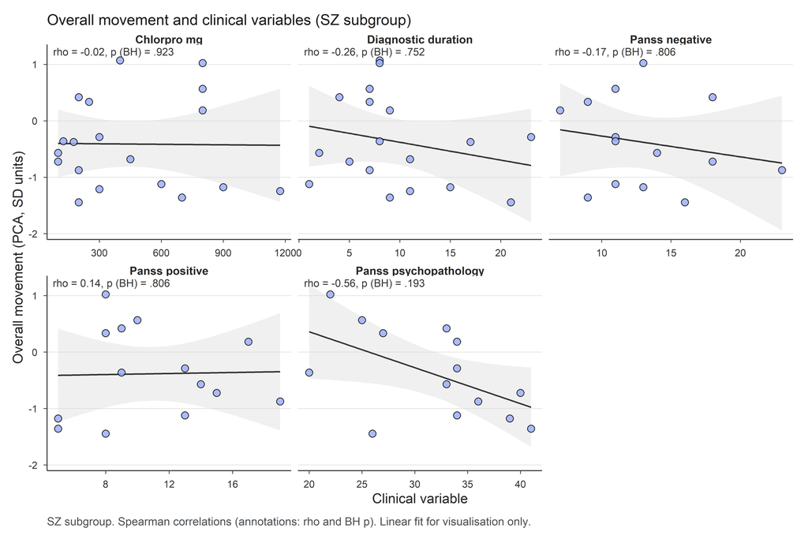

```r
mc_long <- sz_mov |>
  select(move_total_pc1, all_of(clinical_vars)) |>
  pivot_longer(all_of(clinical_vars), names_to = "clinical", values_to = "cval") |>
  filter(!is.na(move_total_pc1), !is.na(cval)) |>
  mutate(clinical = pretty_label(clinical))

ann_mc <- cor_mov_clin |>
  mutate(clinical = pretty_label(y),
         label    = sprintf("rho = %s, %s",
                            fmt_num(rho, 2),
                            ifelse(fmt_p(p_value_BH) == "<.001",
                                   "p (BH) <.001",
                                   paste0("p (BH) = ", fmt_p(p_value_BH)))))

fig_cor_mc <- ggplot(mc_long, aes(x = cval, y = move_total_pc1)) +
  geom_smooth(method = "lm", se = TRUE, colour = "grey20",
              fill = "grey85", linewidth = 0.6) +
  geom_point(shape = 21, fill = GROUP_COLOURS[["SZ"]], colour = "black",
             size = 2.4, alpha = 0.85) +
  geom_text(data = ann_mc, aes(x = -Inf, y = Inf, label = label),
            hjust = -0.05, vjust = 1.4, inherit.aes = FALSE,
            size = 3, colour = "grey20") +
  facet_wrap(~ clinical, scales = "free_x") +
  labs(title   = "Overall movement and clinical variables (SZ subgroup)",
       x       = "Clinical variable",
       y       = "Overall movement (PCA, SD units)",
       caption = paste0(
         "SZ subgroup. Spearman correlations (annotations: rho and BH p). ",
         "Linear fit for visualisation only.")) +
  theme_plos() +
  theme(strip.text = element_text(size = 9), axis.text = element_text(size = 8))
fig_cor_mc
```

```r
save_figure(fig_cor_mc, "Fig7_movement_clinical_correlations", RESULTS_SUPPLEMENTARY,
            width = 9, height = 6)
```

```
## Saved: ../../results/supplementary/Fig7_movement_clinical_correlations.tif and ../../results/supplementary/Fig7_movement_clinical_correlations.png
```

**Fig 7. Exploratory correlations between overall body movement and clinical variables (SZ subgroup).** Spearman correlations; annotations show *ρ* and BH-adjusted *p*-values.

## 11.2 Clinical characteristics and total first-impression score

```r
# Per-stimulus mean total impression score (SZ subgroup)
imp_by_stim <- data_complete |>
  filter(!is.na(imp_total_score)) |>
  group_by(stim_id) |>
  summarise(imp_total_mean = mean(imp_total_score), .groups = "drop")

sz_clin_imp <- sz_only |>
  left_join(imp_by_stim, by = "stim_id")

cor_clin_imp <- spearman_multi(
  sz_clin_imp, y = "imp_total_mean", xs = clinical_vars,
  bh_correction = TRUE
)

cor_clin_imp_tab <- cor_clin_imp |>
  mutate(
    Clinical     = pretty_label(x),
    n            = n,
    `ρ (95% CI)` = sprintf("%s %s", fmt_num(rho, 2), fmt_ci(ci_lo, ci_hi, 2)),
    p            = fmt_p(p_value),
    `p (BH)`     = fmt_p(p_value_BH)
  ) |>
  select(Clinical, n, `ρ (95% CI)`, p, `p (BH)`)

ft_cor_clin_imp <- plos_table(
  cor_clin_imp_tab,
  title    = "Exploratory Spearman correlations between clinical variables and the total first-impression score (SZ subgroup).",
  footnote = c(
    paste0("SZ subgroup only. The first-impression score is the per-stimulus ",
           "mean of the total impression score across observers. ",
           "95% confidence intervals from Fisher's z transformation."),
    paste0("p (BH): Benjamini-Hochberg adjusted p-value across the clinical ",
           "variables. Exploratory.")
  )
)
ft_cor_clin_imp
```

Exploratory Spearman correlations between clinical variables and the total first-impression score (SZ subgroup).

| Clinical | n | ρ (95% CI) | p | p (BH) |
| --- | --- | --- | --- | --- |
| Panss negative | 15 | 0.01 [-0.51, 0.52] | .980 | .980 |
| Panss positive | 15 | 0.20 [-0.35, 0.64] | .480 | .800 |
| Panss psychopathology | 15 | -0.60 [-0.85, -0.13] | .017 | .087 |
| Diagnostic duration | 19 | -0.03 [-0.48, 0.43] | .906 | .980 |
| Chlorpro mg | 20 | -0.32 [-0.67, 0.15] | .173 | .433 |

SZ subgroup only. The first-impression score is the per-stimulus mean of the total impression score across observers. 95% confidence intervals from Fisher's z transformation.  
p (BH): Benjamini-Hochberg adjusted p-value across the clinical variables. Exploratory.

```r
save_table(ft_cor_clin_imp, "table_16_clinical_impression_correlations", RESULTS_SUPPLEMENTARY)
```

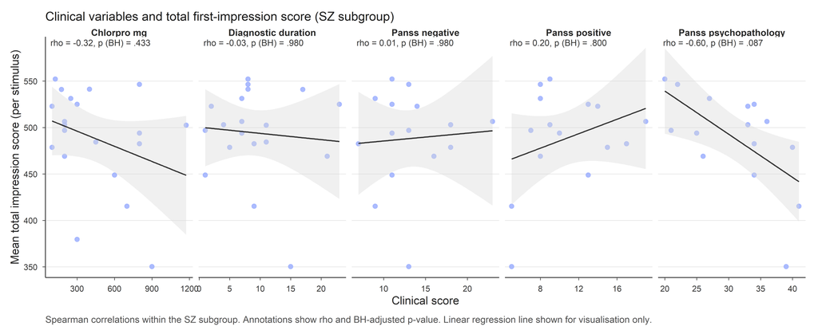

```r
scatter_ci <- sz_clin_imp |>
  select(all_of(clinical_vars), imp_total_mean) |>
  pivot_longer(all_of(clinical_vars), names_to = "clinical", values_to = "cv") |>
  mutate(clinical = pretty_label(clinical))

ann_ci <- cor_clin_imp |>
  mutate(clinical = pretty_label(x),
         label    = sprintf("rho = %s, %s",
                            fmt_num(rho, 2),
                            ifelse(fmt_p(p_value_BH) == "<.001",
                                   "p (BH) <.001",
                                   paste0("p (BH) = ", fmt_p(p_value_BH)))))

fig_cor_ci <- ggplot(scatter_ci, aes(x = cv, y = imp_total_mean)) +
  geom_point(colour = GROUP_COLOURS["SZ"], alpha = 0.85, size = 1.8) +
  geom_smooth(method = "lm", se = TRUE, colour = "grey20",
              fill = "grey85", linewidth = 0.6) +
  geom_text(data = ann_ci, aes(x = -Inf, y = Inf, label = label),
            hjust = -0.05, vjust = 1.4, inherit.aes = FALSE,
            size = 3, colour = "grey20") +
  facet_wrap(~ clinical, scales = "free_x", nrow = 1) +
  labs(title   = "Clinical variables and total first-impression score (SZ subgroup)",
       x       = "Clinical score",
       y       = "Mean total impression score (per stimulus)",
       caption = paste0(
         "Spearman correlations within the SZ subgroup. ",
         "Annotations show rho and BH-adjusted p-value. ",
         "Linear regression line shown for visualisation only.")) +
  theme_plos() +
  theme(strip.text = element_text(size = 9),
        axis.text  = element_text(size = 8))
fig_cor_ci
```

```r
save_figure(fig_cor_ci, "Fig8_clinical_impression_correlations", RESULTS_SUPPLEMENTARY,
            width = 12, height = 4.5)
```

```
## Saved: ../../results/supplementary/Fig8_clinical_impression_correlations.tif and ../../results/supplementary/Fig8_clinical_impression_correlations.png
```

**Fig 8. Exploratory correlations between clinical variables and the total first-impression score (SZ subgroup).** Spearman correlations; annotations show *ρ* and BH-adjusted *p*-values.

# 12 Discussion notes

This notebook produces the descriptive and inferential outputs for the corresponding manuscript, organised by hypothesis under `results/`: `descriptive/` (purely descriptive tables), `H1/` through `H4/` (one folder per hypothesis, each with its tables, figures, diagnostics and bootstrap sensitivity check), and `supplementary/` (scale reliability, the movement PCA construction, and exploratory/symptom correlations). Tables are exported as Word `.docx` (cell-based) and figures as TIFF (300 dpi) and PNG (inline viewing).

Every linear mixed model reports both the marginal/conditional *R²* and an explicit partition of the random variance (variance components, proportion of residual variance, ICC), so that the share of information captured by the observer and video random effects is visible.

The interpretation of effect sizes, clinical implications, and limitations should be developed in the manuscript itself.

# 13 Supporting information

**S1 Table. Cronbach’s α if each item is dropped.** Internal-consistency diagnostic of the first-impression scale. See `results/supplementary/table_S1_cronbach_if_dropped.docx`.

**S2 Table. Diagnostic checks for the total first-impression-score LMM (H1).** Residual normality (Shapiro–Wilk), homoscedasticity (Breusch–Pagan-type auxiliary regression), random-effect normality (Shapiro–Wilk on the BLUPs of `obs_id` and `vid`), singular-fit and convergence flags. See `results/H1/table_S2_lmm_total_diagnostics.docx`.

**S3 Table. Diagnostic checks for the 10 item-level LMMs (H1).** As S2, per item.

**S4 Table. Diagnostic checks for the overall-movement impression LMM (H3).** As S2, for the model using the overall movement score (aggregate PCA component) as a single fixed effect. See `results/H3/table_S4_lmm_movement_diagnostics.docx`.

**S5 Table. Diagnostic checks for the group + movement first-impression LMM (H4).** As S2, for the model with diagnostic group and overall movement entered jointly. See `results/H4/table_S5_lmm_group_movement_diagnostics.docx`.

**S1 Figure. Scree plot of the movement-feature PCA.** Eigenvalues of the components with the Kaiser reference line (eigenvalue = 1). File: `results/supplementary/FigS1_pca_scree.{tiff,png}`.

**S Figures. Diagnostic plots from `performance::check_model()`.** Residual, QQ, posterior-predictive and random-effect diagnostic panels for each LMM. Files: `results/H1/diag_lmm_*.png`, `results/H3/diag_lmm_*.png`, `results/H4/diag_lmm_*.png`.

**S1 File. Processed long data set.** `data/questionnaire_and_merged/02_data_complete.csv` — one row per observer × video evaluation.

**S2 File. Stimulus-level data set.** `data/questionnaire_and_merged/02_data_stimuli.csv` — one row per stimulus.

**S3 File. Observer-level data set.** `data/questionnaire_and_merged/02_data_observers.csv` — one row per observer.

**S4 File. PC1-augmented data sets.** `results/supplementary/data_complete_with_movement_pc1.csv` and `results/supplementary/data_stimuli_with_movement_pc1.csv` — the same tables with the aggregate movement score (`move_total_pc1`) added.

# 14 References

1. Bates D, Mächler M, Bolker B, Walker S. Fitting linear mixed-effects models using lme4. *J Stat Softw.* 2015;67(1):1–48.
2. Kuznetsova A, Brockhoff PB, Christensen RHB. lmerTest package: tests in linear mixed effects models. *J Stat Softw.* 2017;82(13):1–26.
3. Nakagawa S, Schielzeth H. A general and simple method for obtaining R² from generalized linear mixed-effects models. *Methods Ecol Evol.* 2013;4(2):133–142.
4. Lenth RV. emmeans: estimated marginal means, aka least-squares means. *R package version 1.x.x.*
5. Lüdecke D, Ben-Shachar MS, Patil I, Waggoner P, Makowski D. performance: an R package for assessment, comparison and testing of statistical models. *J Open Source Softw.* 2021;6(60):3139.
6. Benjamini Y, Hochberg Y. Controlling the false discovery rate: a practical and powerful approach to multiple testing. *J R Stat Soc B.* 1995;57(1):289–300.
7. Lang T, Altman D. Basic statistical reporting for articles published in clinical medical journals: the SAMPL Guidelines. In: Smart P, Maisonneuve H, Polderman A, editors. *Science Editors’ Handbook.* European Association of Science Editors; 2013.

[session information not shown]